{% raw %}

# Stress test most optimal exit strategy

Now that I've created two separate exit strategies, I think it'd be most optimal to then stress test them in 10,000 random signals, and see which one produced the best results. Currently there are four options to test.

1. Gap test
2. Scorecard test
3. Scorecard AND Gap test
4. Scorecard OR Cap test

The following underneath gives some detail about how the exit strategy is operated:

> **More sophisticated exit strategy + new params**

Currently the code simply runs how many days of consec is detected to be negative, and if it reaches said length, or reaches beyond stop loss, it is pulled. One hidden params was when the exit strategy starts running, aka operating at a delay.

I had it set to 1 day delay, to allow for noise, but figured what if I could control both the delay of exit strat start, in addition to the gaps between identifying the losses?

For example, I could set the exit strat to start on `Day 2` of the trade, and during it's first trade, it'll look at whether the loss has been reached by `1 Day` apart. If it passes, it can be check every `2 Days` instead of 1, but returns to `1 Day` check if the loss reaches it's threshold. Allowing for more playing and param testing.

```
# check for consecutive negatives - one of the exit rules applied
            cons_neg = 0
            exit_offset = len(full_window) - 1 # this is utilized when concsecutive neg is not triggered, and exits automatically when reaching to length of window

            phase = 1
            i = exit_strat_delay  # start AFTER delay

            while i < len(full_window) - 1:

                step = check_gap_first if phase == 1 else check_gap_rest
                j = i + step

                if j >= len(full_window):
                    break

                d = closes[j] - closes[i]

                if d < 0:
                    cons_neg += 1
                else:
                   cons_neg = 0

                if cons_neg >= exit_on_consec_losses:
                  exit_offset = j
                  break

                pct_change = (closes[j] - closes[i]) / closes[i]

                if pct_change <= stop_loss_pct:
                    exit_offset = j
                    break

               # --- phase switching MUST be inside loop ---
                if phase == 1:
                    phase = 2
                else:
                    if d < 0:
                        phase = 1

                i = j
```

> **New scorecard point system for exit strategy**

Because of how gap strategy functioned, I wondered if I could go even thinner and track the values from open, to close, to the following open, rinse and repeat instead? Checking for intraday and overnight values.

Like the gap, I also added an exit strategy delay - the crux of the strategy works as follows:

[figure not shown]

What it does is for every proceeding negative return, 1 point is added - for every positive, 1 point is redacted up till baseline of 0. When the points are added up to say, 3, the stock will then sell on that signal. The params allows for control of how much intraday or overnight difference will weigh, and the amount of points that is to be reached as well.

```
def score_exit_strategy(
    closes,
    opens,
    exit_strat_delay,
    intraday_weight,
    overnight_weight,
    exit_score_threshold,
    stop_loss_pct)
```

> **Fixing exit timing of scorecard**

I noticed that the code might be exiting the strategy at `Close` due to the fact that I've set exit strat during closing time. Some changes were made with the function and compute function itself, so that it accepted a new variable `Open` as the exit.

### Notebook updates

> **Keeping VIX and SP500 constraint:**

> **Running iterations for scorecard + multi params**

So during my first run with `scorecard`, I didn't make changes to the params that effect both `gap` and `score`. Once I've finished the run on `gap`, I've pulled out the full params sweep `.csv` data, and looked at the best performing exit strategies in `scorecard` and `gap` to then make adjustments to the multi params (as I haven't changed it during `score` iteration).

I made some educated guesses on what to keep and remove, while slightly adjusting the original values of `multiparams` that were deemed to be too little to change anything of value.

> **Missing exit_on_consec_losses value in .csv**

I've noticed the data is actually missing this specific param while siphoning for the best results, meaning I wouldn't know which one utilised either `2` or `3` within the `gap` iteration - because of the time it took to go through 432 options (over 2 hours), I'll have to settle with the gaps given from the 432 second iteration of `score`, now with `exit_on_consec_losses` included.

> **Another lookahead bias bug in scorecard**

I knew to be of suspicious with scorecard, as it was detecting the drop of tickers, but exiting ONLY at `open` instead of some at `open` and `close`.

```python
import yfinance as yf
import pandas as pd
import time
import os
import time
import matplotlib.pyplot as plt
import numpy as np
import matplotlib.dates as mdates
from itertools import product
from matplotlib.colors import LinearSegmentedColormap
from datetime import datetime
import joblib
```

```python
# get all data into the notebook

close_path = "data/parquet/nasdaq_prices.parquet" # closing prices
open_path = "data/parquet/nasdaq_open_prices.parquet" # opening prices
sp_path = 'data/^spx_d.csv' # s&p 500 data
vix_hist = 'data\VIX_History.csv' # vix data

prices = pd.read_parquet(close_path)
open_price = pd.read_parquet(open_path)
sp500 = pd.read_csv(sp_path)
df_vix = pd.read_csv(vix_hist)

# double check the y-axis shape are same so we don't have missing data.
prices.shape, open_price.shape
```

```
((9165, 5334), (9165, 5334))
```

```python
# Define start date for subset
start_date = "2022-01-01"

# Subset all dataframes to start_date
prices_recent = prices.loc[prices.index >= start_date]
open_prices_recent = open_price.loc[open_price.index >= start_date]

print(f"Subset prices shape: {prices_recent.shape}")
print(f"Subset open prices shape: {open_prices_recent.shape}")
```

```
Subset prices shape: (1101, 5334)
Subset open prices shape: (1101, 5334)
```

```python
prices_recent.head()
```

| Ticker Date | AACB | AACOU | AACBR | AACIU | AACBU | AACG | AAEQ | AALG | AADR | AAOI | ... | ZWZZT | ZVRA | ZTOP | ZXZZT | 0310202615:41 | CREATION | ZYBT | ZYME | FILE | TIME: |
| --- | --- | --- | --- | --- | --- | --- | --- | --- | --- | --- | --- | --- | --- | --- | --- | --- | --- | --- | --- | --- | --- |
| 2022-01-03 | NaN | NaN | NaN | NaN | NaN | 1.19 | NaN | NaN | 60.362926 | 5.27 | ... | NaN | 9.26 | NaN | NaN | NaN | NaN | NaN | 16.980000 | NaN | NaN |
| 2022-01-04 | NaN | NaN | NaN | NaN | NaN | 2.55 | NaN | NaN | 60.344181 | 5.29 | ... | NaN | 8.76 | NaN | NaN | NaN | NaN | NaN | 16.200001 | NaN | NaN |
| 2022-01-05 | NaN | NaN | NaN | NaN | NaN | 2.30 | NaN | NaN | 59.369530 | 5.03 | ... | NaN | 8.35 | NaN | NaN | NaN | NaN | NaN | 15.100000 | NaN | NaN |
| 2022-01-06 | NaN | NaN | NaN | NaN | NaN | 1.98 | NaN | NaN | 59.660042 | 4.77 | ... | NaN | 8.40 | NaN | NaN | NaN | NaN | NaN | 14.070000 | NaN | NaN |
| 2022-01-07 | NaN | NaN | NaN | NaN | NaN | 2.64 | NaN | NaN | 59.660042 | 4.69 | ... | NaN | 8.63 | NaN | NaN | NaN | NaN | NaN | 14.110000 | NaN | NaN |

5 rows × 5334 columns

```python
def restructure_data(prices):
    df = (
        prices
        .stack()
        .reset_index(name="Close")
        .rename(columns={"level_0": "Date", "level_1": "Ticker"})
    )

    df = df.sort_values(["Ticker", "Date"])

    return df
```

```python
df = restructure_data(prices_recent)
```

```python
df
```

|  | Date | Ticker | Close |
| --- | --- | --- | --- |
| 2794428 | 2025-04-07 | AACB | 9.880000 |
| 2798525 | 2025-04-08 | AACB | 9.950000 |
| 2802626 | 2025-04-09 | AACB | 9.900000 |
| 2806731 | 2025-04-10 | AACB | 9.890000 |
| 2810841 | 2025-04-11 | AACB | 9.885000 |
| ... | ... | ... | ... |
| 4087959 | 2026-05-18 | ZYME | 24.430000 |
| 4093101 | 2026-05-19 | ZYME | 24.400000 |
| 4098248 | 2026-05-20 | ZYME | 24.840000 |
| 4103404 | 2026-05-21 | ZYME | 25.110001 |
| 4108601 | 2026-05-22 | ZYME | 25.610001 |

4108602 rows × 3 columns

```python
df_open_long = (open_prices_recent.stack().reset_index())
df_open_long = df_open_long.sort_values(["Ticker","Date"])
df_open_long = df_open_long.rename(columns={0:'Open'})
```

```python
def gap_exit_strategy(
    closes,
    exit_strat_delay,
    check_gap_first,
    check_gap_rest,
    exit_on_consec_losses,
    stop_loss_pct
):

    cons_neg = 0
    exit_offset = len(closes) - 1

    phase = 1
    i = exit_strat_delay

    while i < len(closes) - 1:

        step = check_gap_first if phase == 1 else check_gap_rest
        j = i + step

        if j >= len(closes):
            break

        d = closes[j] - closes[i]

        if d < 0:
            cons_neg += 1
        else:
            cons_neg = 0

        if cons_neg >= exit_on_consec_losses:
            return j

        pct_change = (closes[j] - closes[i]) / closes[i]

        if pct_change <= stop_loss_pct:
            return j

        if phase == 1:
            phase = 2
        else:
            if d < 0:
                phase = 1

        i = j

    return exit_offset
```

```python
def score_exit_strategy(
    closes,
    opens,
    exit_strat_delay,
    intraday_weight,
    overnight_weight,
    exit_score_threshold,
    stop_loss_pct,
):
    score = 0
    exit_offset = len(closes) - 1
    exit_type_override = "close"

    for j in range(exit_strat_delay, len(closes) - 1):
        # intraday
        intraday_move = closes[j] - opens[j]

        if intraday_move < 0:
            score += intraday_weight
        else:
            score = max(0, score - intraday_weight)

        # If score reached on intraday, return with `close`
        if score >= exit_score_threshold:
            return j, "close"

        # stop loss (FIXED: Now returns tuple to match expected format)
        if j > 0:
            pct_change = (closes[j] - closes[j - 1]) / closes[j - 1]
            if pct_change <= stop_loss_pct:
                return j, "close"

        # overnight
        if j + 1 < len(closes):
            overnight_move = opens[j + 1] - closes[j]

            if overnight_move < 0:
                score += overnight_weight
            else:
                score = max(0, score - overnight_weight)

        if score >= exit_score_threshold:
            return j, "open"

    return exit_offset, exit_type_override
```

```python
def compute_trade_returns(
    df_open,
    df_price_history,
    true_signal,
    run_id="default_run",
    max_hold=100,
    exit_on_consec_losses=2,
    stop_loss_pct=-0.05,
    entry_at="open",
    exit_at="close",
    entry_delay=5,
    exit_strategy="scorecard",
    # GAP
    exit_strat_delay=2,
    check_gap_first=1,
    check_gap_rest=2,
    # SCORE
    intraday_weight=1.0,
    overnight_weight=1.0,
    exit_score_threshold=4,
):
    trades = []

    # ==================================================
    # SIGNAL DATA
    # ==================================================
    df_open = df_open.sort_values(["Ticker", "Date"]).copy()
    df_open["Date"] = pd.to_datetime(df_open["Date"])

    df_price_history = df_price_history.merge(
        df_open[["Ticker", "Date", "Open"]], on=["Ticker", "Date"], how="left"
    )

    if df_price_history["Open"].isna().any():
        raise ValueError(
            f"{df_price_history['Open'].isna().sum()} rows missing Open prices"
        )

    df_price_history["Date"] = pd.to_datetime(df_price_history["Date"])

    full_price_dict = {
        t: g.sort_values("Date").reset_index(drop=True)
        for t, g in df_price_history.groupby("Ticker")
    }

    df = df_price_history.copy()
    df["signal"] = False
    df.loc[true_signal.index, "signal"] = True

    signal_shifted = (
        df.groupby("Ticker")["signal"]
        .shift(entry_delay)
        .fillna(False)
        .astype(bool)
    )

    # ==================================================
    # MAIN LOOP
    # ==================================================
    for ticker, g in df_price_history.groupby("Ticker"):
        g = g.reset_index()

        sig_entry = signal_shifted.loc[g["index"]].values
        entry_idxs = np.where(sig_entry)[0]

        if ticker not in full_price_dict:
            continue

        full_g = full_price_dict[ticker]

        for e in entry_idxs:
            signal_idx = max(e - entry_delay, 0)
            signal_date = g.iloc[signal_idx]["Date"]
            entry_date = g.iloc[e]["Date"]

            full_match = full_g.index[full_g["Date"] == entry_date]
            if len(full_match) == 0:
                continue

            full_entry_idx = full_match[0]

            window = full_g.iloc[
                full_entry_idx : full_entry_idx + max_hold + 1
            ]

            if len(window) <= 1:
                continue

            closes = window["Close"].values

            if "Open" in window.columns:
                opens = window["Open"].values
            else:
                opens = closes

            entry_price = opens[0] if entry_at == "open" else closes[0]

            # ==================================================
            # EXIT STRATEGY
            # ==================================================
            if exit_strategy == "gap":
                # SWAPPED: Single output assignment + fallback injection to protect against unpack errors
                exit_offset = gap_exit_strategy(
                    closes,
                    exit_strat_delay,
                    check_gap_first,
                    check_gap_rest,
                    exit_on_consec_losses,
                    stop_loss_pct,
                )
                active_exit_at = "close"

            elif exit_strategy == "scorecard":
                exit_offset, active_exit_at = score_exit_strategy(
                    closes,
                    opens,
                    exit_strat_delay,
                    intraday_weight,
                    overnight_weight,
                    exit_score_threshold,
                    stop_loss_pct,
                )

            else:
                raise ValueError("exit_strategy must be 'gap' or 'scorecard'")

            # SWAPPED: Added a validation check to let active_exit_at fall back to the default exit_at setting
            chosen_execution = active_exit_at if 'active_exit_at' in locals() else exit_at
            exit_price = (
                opens[exit_offset]
                if chosen_execution == "open"
                else closes[exit_offset]
            )

            trades.append(
                {
                    "run_id": run_id,
                    "ticker": ticker,
                    "entry_date": entry_date,
                    "signal_date": signal_date,
                    "entry_idx": full_entry_idx,
                    "exit_idx": full_entry_idx + exit_offset,
                    "entry_price": entry_price,
                    "exit_price": exit_price,
                    "return": (exit_price - entry_price) / entry_price,
                    "hold_days": exit_offset,
                    "exit_strategy": exit_strategy,
                    # parameters snapshot (IMPORTANT FOR SWEEPS)
                    "exit_strat_delay": exit_strat_delay,
                    "check_gap_first": check_gap_first,
                    "check_gap_rest": check_gap_rest,
                    "intraday_weight": intraday_weight,
                    "overnight_weight": overnight_weight,
                    "exit_score_threshold": exit_score_threshold,
                    "stop_loss_pct": stop_loss_pct,
                    "entry_delay": entry_delay,
                }
            )

    trades_df = pd.DataFrame(trades)

    if len(trades_df) > 0:
        trades_df = trades_df.dropna(subset=["exit_price"])

    # ==================================================
    # CSV LOGGING (MINIMAL STRUCTURAL INDEXING)
    # ==================================================
    trade_file = "trade_events.csv"
    run_file = "run_params.csv"

    # Calculate average daily return profile per trade (avoiding division by zero)
    if len(trades_df) > 0:
        trades_df["return_per_day"] = np.where(
            trades_df["hold_days"] > 0,
            trades_df["return"] / trades_df["hold_days"],
            trades_df["return"],
        )

    # ---- trade log (ONLY run_id, ticker, entry_idx, exit_idx) ----
    if len(trades_df) > 0:
        trade_export = trades_df[
            ["run_id", "ticker", "entry_idx", "exit_idx"]
        ].copy()
    else:
        trade_export = pd.DataFrame(
            columns=["run_id", "ticker", "entry_idx", "exit_idx"]
        )

    if os.path.exists(trade_file) and os.path.getsize(trade_file) > 0:
        old = pd.read_csv(trade_file)
        trade_export = pd.concat([old, trade_export], ignore_index=True)

    trade_export.to_csv(trade_file, index=False)

    # ---- run params log + performance tracking ----
    run_row = pd.DataFrame(
        [
            {
                "run_id": run_id,
                "exit_strategy": exit_strategy,
                "exit_strat_delay": exit_strat_delay,
                "exit_on_consec_losses": exit_on_consec_losses,
                "check_gap_first": check_gap_first,
                "check_gap_rest": check_gap_rest,
                "intraday_weight": intraday_weight,
                "overnight_weight": overnight_weight,
                "exit_score_threshold": exit_score_threshold,
                "stop_loss_pct": stop_loss_pct,
                "entry_delay": entry_delay,
                "timestamp": datetime.now(),
                # Aggregated Metrics Relational Storage
                "n_trades": len(trades_df),
                "mean_return": trades_df["return"].mean() if len(trades_df) else 0,
                "median_return": (
                    trades_df["return"].median() if len(trades_df) else 0
                ),
                "win_rate": (
                    (trades_df["return"] > 0).mean() if len(trades_df) else 0
                ),
                "avg_return_per_day": (
                    trades_df["return_per_day"].mean() if len(trades_df) else 0
                ),
            }
        ]
    )

    # FIXED: Re-added the file append completion logic that cut off
    if os.path.exists(run_file) and os.path.getsize(run_file) > 0:
        old_runs = pd.read_csv(run_file)
        run_row = pd.concat([old_runs, run_row], ignore_index=True)

    run_row.to_csv(run_file, index=False)

    return trades_df
```

```python
from joblib import Parallel, delayed
from tqdm import tqdm
import time

# ─────────────────────────────────────────────────────────────────────────────
# trade_events helpers  (main-process only — never call from workers)
# ─────────────────────────────────────────────────────────────────────────────
TRADE_EVENTS_FILE = "trade_events.csv"
_TE_COLS = ["run_id", "ticker", "entry_idx", "exit_idx"]   # the ONLY columns stored


def _load_trade_events(path: str) -> "pd.DataFrame":
    """Read trade_events.csv; return an empty frame if missing or corrupt."""
    import pandas as pd, os
    if not os.path.exists(path) or os.path.getsize(path) == 0:
        return pd.DataFrame(columns=_TE_COLS)
    try:
        return pd.read_csv(path, usecols=_TE_COLS)[_TE_COLS]
    except Exception:
        # file is corrupt — start fresh rather than propagating bad data
        return pd.DataFrame(columns=_TE_COLS)


def _save_trade_events(new_rows: "pd.DataFrame", path: str) -> None:
    """
    Append new_rows to trade_events.csv in one atomic write.
    Only the four canonical columns are ever written; everything else is dropped.
    Uses a .tmp → rename pattern so a crash mid-write can't corrupt the file.
    """
    import pandas as pd, os
    if new_rows.empty:
        return

    # drop any extra columns that compute_trade_returns may have added
    rows_to_add = new_rows[[c for c in _TE_COLS if c in new_rows.columns]].copy()

    existing = _load_trade_events(path)
    combined = pd.concat([existing, rows_to_add], ignore_index=True)

    tmp = path + ".tmp"
    combined.to_csv(tmp, index=False)
    os.replace(tmp, path)   # atomic on Windows + POSIX
# ─────────────────────────────────────────────────────────────────────────────


def run_sweep(
    df_open,
    df_price_history,
    true_signal,
    param_grid,
    run_prefix="run",
):
    import itertools
    import pandas as pd
    import os

    keys = list(param_grid.keys())
    combos = list(itertools.product(*param_grid.values()))
    total_combos = len(combos)

    # ==================================================
    # 1. READ EXISTING PARAMETERS LOG
    # ==================================================
    gap_counter = 0
    score_counter = 0
    run_file = "run_params.csv"
    existing_runs = pd.DataFrame()

    if os.path.exists(run_file) and os.path.getsize(run_file) > 0:
        try:
            existing_runs = pd.read_csv(run_file)
            if "run_id" in existing_runs.columns:
                gap_ids   = existing_runs[existing_runs["run_id"].str.startswith("gap_",   na=False)]["run_id"]
                score_ids = existing_runs[existing_runs["run_id"].str.startswith("score_", na=False)]["run_id"]
                if not gap_ids.empty:
                    gap_counter   = gap_ids.str.extract(r"(\d+)").astype(int).max().iloc[0] + 1
                if not score_ids.empty:
                    score_counter = score_ids.str.extract(r"(\d+)").astype(int).max().iloc[0] + 1
        except Exception:
            pass

    # ==================================================
    # 2. PLANNING PASS — dedup + run_id assignment (main process only)
    # ==================================================
    jobs = []
    for i, combo in enumerate(combos):
        params = dict(zip(keys, combo))
        strategy_type        = params.get("strategy")
        exit_strat_delay     = params.get("exit_strat_delay", 2)
        check_gap_first      = params.get("check_gap_first", 1)
        check_gap_rest       = params.get("check_gap_rest", 2)
        intraday_weight      = params.get("intraday_weight", 1.0)
        overnight_weight     = params.get("overnight_weight", 1.0)
        exit_score_threshold = params.get("exit_score_threshold", 4)
        stop_loss_pct        = params.get("stop_loss_pct", -0.05)
        entry_delay          = params.get("entry_delay", 1)

        if not existing_runs.empty:
            dup = (
                (existing_runs["exit_strategy"]          == strategy_type)
                & (existing_runs["exit_strat_delay"]     == exit_strat_delay)
                & (existing_runs["check_gap_first"]      == check_gap_first)
                & (existing_runs["check_gap_rest"]       == check_gap_rest)
                & (existing_runs["intraday_weight"]      == intraday_weight)
                & (existing_runs["overnight_weight"]     == overnight_weight)
                & (existing_runs["exit_score_threshold"] == exit_score_threshold)
                & (existing_runs["stop_loss_pct"]        == stop_loss_pct)
                & (existing_runs["entry_delay"]          == entry_delay)
            )
            if dup.any():
                skipped_id = existing_runs.loc[dup, "run_id"].values[0]
                print(f"⏭️  Skipping combo {i+1}/{total_combos} — already logged as: {skipped_id}")
                continue

        if strategy_type == "gap":
            assigned_run_id = f"gap_{gap_counter}";    gap_counter   += 1
        elif strategy_type == "scorecard":
            assigned_run_id = f"score_{score_counter}"; score_counter += 1
        else:
            assigned_run_id = f"{run_prefix}_{i}"

        jobs.append({
            "run_id":                assigned_run_id,
            "strategy":              strategy_type,
            "exit_on_consec_losses": params.get("exit_on_consec_losses", 2),
            "exit_strat_delay":      exit_strat_delay,
            "stop_loss_pct":         stop_loss_pct,
            "entry_delay":           entry_delay,
            "check_gap_first":       check_gap_first,
            "check_gap_rest":        check_gap_rest,
            "intraday_weight":       intraday_weight,
            "overnight_weight":      overnight_weight,
            "exit_score_threshold":  exit_score_threshold,
        })

    if not jobs:
        print("Nothing to run — every combination is already logged.")
        return pd.DataFrame(columns=["run_id", "ticker", "entry_idx", "exit_idx", "return"])

    # ==================================================
    # 3. WORKER — pure computation, ZERO file I/O
    #
    #    compute_trade_returns must NOT read or write trade_events.csv
    #    (or any CSV) from inside this function.  Pass write_trade_events=False
    #    if your implementation supports it, otherwise strip that logic out of
    #    compute_trade_returns entirely and let step 5 handle persistence.
    # ==================================================
    def process_one(job):
        df = compute_trade_returns(
            df_open,
            df_price_history,
            true_signal,
            run_id=job["run_id"],
            exit_strategy=job["strategy"],
            exit_on_consec_losses=job["exit_on_consec_losses"],
            exit_strat_delay=job["exit_strat_delay"],
            stop_loss_pct=job["stop_loss_pct"],
            entry_delay=job["entry_delay"],
            check_gap_first=job["check_gap_first"],
            check_gap_rest=job["check_gap_rest"],
            intraday_weight=job["intraday_weight"],
            overnight_weight=job["overnight_weight"],
            exit_score_threshold=job["exit_score_threshold"]
        )
        df["run_id"]   = job["run_id"]
        df["strategy"] = job["strategy"]
        return job["run_id"], job["strategy"], df

    # ==================================================
    # 4. PARALLEL EXECUTION — results stream back to main process in memory
    # ==================================================
    print(f"\n🚀 Running {len(jobs)} combinations in parallel...")
    print("=" * 50)
    start_time = time.time()

    results    = []
    parallel   = Parallel(n_jobs=-3, return_as="generator_unordered")
    job_stream = parallel(delayed(process_one)(job) for job in jobs)

    for run_id, strategy, df in tqdm(job_stream, total=len(jobs), desc="Progress"):
        elapsed = time.time() - start_time
        print(f"✅ Completed {run_id} ({strategy}) — {elapsed:.1f}s elapsed")
        results.append(df)

    elapsed = time.time() - start_time
    print("=" * 50)
    print(f"\n✅ All done in {elapsed:.1f}s  |  {len(results)} combinations processed")

    if not results:
        return pd.DataFrame(columns=["run_id", "ticker", "entry_idx", "exit_idx", "return"])

    all_results = pd.concat(results, ignore_index=True)

    # ==================================================
    # 5. SINGLE ATOMIC WRITE — trade_events.csv
    #
    #    Happens here, in the main process, after every worker has finished.
    #    Stores exactly:  run_id | ticker | entry_idx | exit_idx
    #    Nothing else is ever written to this file.
    # ==================================================
    _save_trade_events(all_results, TRADE_EVENTS_FILE)
    print(f"💾 trade_events.csv updated — {len(all_results):,} new rows written")

    return all_results
```

```python
# test compuitrew
_SKIP_IO = object()   # sentinel: workers pass this to skip all file I/O


def compute_trade_returns(
    df_open,
    df_price_history,
    true_signal,
    run_id="default_run",
    max_hold=100,
    exit_on_consec_losses=2,
    stop_loss_pct=-0.05,
    entry_at="open",
    exit_at="close",
    entry_delay=5,
    exit_strategy="scorecard",
    # GAP
    exit_strat_delay=2,
    check_gap_first=1,
    check_gap_rest=2,
    # SCORE
    intraday_weight=1.0,
    overnight_weight=1.0,
    exit_score_threshold=4,
    _skip_csv=False,   # set True from run_sweep — disables ALL file I/O
):
    trades = []

    # ==================================================
    # SIGNAL DATA
    # ==================================================
    df_open = df_open.sort_values(["Ticker", "Date"]).copy()
    df_open["Date"] = pd.to_datetime(df_open["Date"])

    df_price_history = df_price_history.merge(
        df_open[["Ticker", "Date", "Open"]], on=["Ticker", "Date"], how="left"
    )

    if df_price_history["Open"].isna().any():
        raise ValueError(
            f"{df_price_history['Open'].isna().sum()} rows missing Open prices"
        )

    df_price_history["Date"] = pd.to_datetime(df_price_history["Date"])

    full_price_dict = {
        t: g.sort_values("Date").reset_index(drop=True)
        for t, g in df_price_history.groupby("Ticker")
    }

    df = df_price_history.copy()
    df["signal"] = False
    df.loc[true_signal.index, "signal"] = True

    signal_shifted = (
        df.groupby("Ticker")["signal"]
        .shift(entry_delay)
        .fillna(False)
        .astype(bool)
    )

    # ==================================================
    # MAIN LOOP
    # ==================================================
    for ticker, g in df_price_history.groupby("Ticker"):
        g = g.reset_index()

        sig_entry  = signal_shifted.loc[g["index"]].values
        entry_idxs = np.where(sig_entry)[0]

        if ticker not in full_price_dict:
            continue

        full_g = full_price_dict[ticker]

        for e in entry_idxs:
            signal_idx  = max(e - entry_delay, 0)
            signal_date = g.iloc[signal_idx]["Date"]
            entry_date  = g.iloc[e]["Date"]

            full_match = full_g.index[full_g["Date"] == entry_date]
            if len(full_match) == 0:
                continue

            full_entry_idx = full_match[0]
            window = full_g.iloc[full_entry_idx : full_entry_idx + max_hold + 1]

            if len(window) <= 1:
                continue

            closes = window["Close"].values
            opens  = window["Open"].values if "Open" in window.columns else closes
            entry_price = opens[0] if entry_at == "open" else closes[0]

            # ==================================================
            # EXIT STRATEGY
            # ==================================================
            if exit_strategy == "gap":
                exit_offset    = gap_exit_strategy(
                    closes, exit_strat_delay, check_gap_first,
                    check_gap_rest, exit_on_consec_losses, stop_loss_pct,
                )
                active_exit_at = "close"

            elif exit_strategy == "scorecard":
                exit_offset, active_exit_at = score_exit_strategy(
                    closes, opens, exit_strat_delay, intraday_weight,
                    overnight_weight, exit_score_threshold, stop_loss_pct,
                )

            else:
                raise ValueError("exit_strategy must be 'gap' or 'scorecard'")

            chosen_execution = active_exit_at if "active_exit_at" in locals() else exit_at
            exit_price = opens[exit_offset] if chosen_execution == "open" else closes[exit_offset]

            trades.append({
                "run_id":               run_id,
                "ticker":               ticker,
                "entry_date":           entry_date,
                "signal_date":          signal_date,
                "entry_idx":            full_entry_idx,
                "exit_idx":             full_entry_idx + exit_offset,
                "entry_price":          entry_price,
                "exit_price":           exit_price,
                "return":               (exit_price - entry_price) / entry_price,
                "hold_days":            exit_offset,
                "exit_strategy":        exit_strategy,
                "exit_strat_delay":     exit_strat_delay,
                "check_gap_first":      check_gap_first,
                "check_gap_rest":       check_gap_rest,
                "intraday_weight":      intraday_weight,
                "overnight_weight":     overnight_weight,
                "exit_score_threshold": exit_score_threshold,
                "stop_loss_pct":        stop_loss_pct,
                "entry_delay":          entry_delay,
            })

    trades_df = pd.DataFrame(trades)

    if len(trades_df) > 0:
        trades_df = trades_df.dropna(subset=["exit_price"])
        trades_df["return_per_day"] = np.where(
            trades_df["hold_days"] > 0,
            trades_df["return"] / trades_df["hold_days"],
            trades_df["return"],
        )

    # ==================================================
    # CSV LOGGING
    # _skip_csv=True when called from run_sweep — return immediately,
    # let run_sweep do one safe write after all workers finish.
    # ==================================================
    if _skip_csv:
        return trades_df

    # Direct call path — write both CSVs now
    trade_file = "trade_events.csv"
    run_file   = "run_params.csv"

    trade_export = (
        trades_df[["run_id", "ticker", "entry_idx", "exit_idx"]].copy()
        if len(trades_df) > 0
        else pd.DataFrame(columns=["run_id", "ticker", "entry_idx", "exit_idx"])
    )
    if os.path.exists(trade_file) and os.path.getsize(trade_file) > 0:
        trade_export = pd.concat([pd.read_csv(trade_file), trade_export], ignore_index=True)
    tmp = trade_file + ".tmp"
    trade_export.to_csv(tmp, index=False)
    os.replace(tmp, trade_file)

    run_row = pd.DataFrame([{
        "run_id":                run_id,
        "exit_strategy":         exit_strategy,
        "exit_strat_delay":      exit_strat_delay,
        "exit_on_consec_losses": exit_on_consec_losses,
        "check_gap_first":       check_gap_first,
        "check_gap_rest":        check_gap_rest,
        "intraday_weight":       intraday_weight,
        "overnight_weight":      overnight_weight,
        "exit_score_threshold":  exit_score_threshold,
        "stop_loss_pct":         stop_loss_pct,
        "entry_delay":           entry_delay,
        "timestamp":             datetime.now(),
        "n_trades":              len(trades_df),
        "mean_return":           trades_df["return"].mean()         if len(trades_df) else 0,
        "median_return":         trades_df["return"].median()       if len(trades_df) else 0,
        "win_rate":              (trades_df["return"] > 0).mean()   if len(trades_df) else 0,
        "avg_return_per_day":    trades_df["return_per_day"].mean() if len(trades_df) else 0,
    }])
    if os.path.exists(run_file) and os.path.getsize(run_file) > 0:
        run_row = pd.concat([pd.read_csv(run_file), run_row], ignore_index=True)
    run_row.to_csv(run_file, index=False)

    return trades_df
```

```python
# TEST SWEEP
from joblib import Parallel, delayed
from tqdm import tqdm
import time


def run_sweep(
    df_open,
    df_price_history,
    true_signal,
    param_grid,
    run_prefix="run",
):
    import itertools
    import pandas as pd
    import numpy as np
    import os
    from datetime import datetime

    keys         = list(param_grid.keys())
    combos       = list(itertools.product(*param_grid.values()))
    total_combos = len(combos)

    # ==================================================
    # 1. READ EXISTING LOGS
    # ==================================================
    gap_counter   = 0
    score_counter = 0
    run_file      = "run_params.csv"
    trade_file    = "trade_events.csv"
    existing_runs = pd.DataFrame()

    if os.path.exists(run_file) and os.path.getsize(run_file) > 0:
        try:
            existing_runs = pd.read_csv(run_file)
            if "run_id" in existing_runs.columns:
                gap_ids   = existing_runs[existing_runs["run_id"].str.startswith("gap_",   na=False)]["run_id"]
                score_ids = existing_runs[existing_runs["run_id"].str.startswith("score_", na=False)]["run_id"]
                if not gap_ids.empty:
                    gap_counter   = gap_ids.str.extract(r"(\d+)").astype(int).max().iloc[0] + 1
                if not score_ids.empty:
                    score_counter = score_ids.str.extract(r"(\d+)").astype(int).max().iloc[0] + 1
        except Exception:
            pass

    # ==================================================
    # 2. PLANNING PASS
    # ==================================================
    jobs = []
    for i, combo in enumerate(combos):
        params = dict(zip(keys, combo))
        strategy_type        = params.get("strategy")
        exit_strat_delay     = params.get("exit_strat_delay", 2)
        check_gap_first      = params.get("check_gap_first", 1)
        check_gap_rest       = params.get("check_gap_rest", 2)
        intraday_weight      = params.get("intraday_weight", 1.0)
        overnight_weight     = params.get("overnight_weight", 1.0)
        exit_score_threshold = params.get("exit_score_threshold", 4)
        stop_loss_pct        = params.get("stop_loss_pct", -0.05)
        entry_delay          = params.get("entry_delay", 1)

        if not existing_runs.empty:
            dup = (
                (existing_runs["exit_strategy"]          == strategy_type)
                & (existing_runs["exit_strat_delay"]     == exit_strat_delay)
                & (existing_runs["check_gap_first"]      == check_gap_first)
                & (existing_runs["check_gap_rest"]       == check_gap_rest)
                & (existing_runs["intraday_weight"]      == intraday_weight)
                & (existing_runs["overnight_weight"]     == overnight_weight)
                & (existing_runs["exit_score_threshold"] == exit_score_threshold)
                & (existing_runs["stop_loss_pct"]        == stop_loss_pct)
                & (existing_runs["entry_delay"]          == entry_delay)
            )
            if dup.any():
                skipped_id = existing_runs.loc[dup, "run_id"].values[0]
                print(f"⏭️  Skipping combo {i+1}/{total_combos} — already logged as: {skipped_id}")
                continue

        if strategy_type == "gap":
            assigned_run_id = f"gap_{gap_counter}";     gap_counter   += 1
        elif strategy_type == "scorecard":
            assigned_run_id = f"score_{score_counter}"; score_counter += 1
        else:
            assigned_run_id = f"{run_prefix}_{i}"

        jobs.append({
            "run_id":                assigned_run_id,
            "strategy":              strategy_type,
            "exit_on_consec_losses": params.get("exit_on_consec_losses", 2),
            "exit_strat_delay":      exit_strat_delay,
            "stop_loss_pct":         stop_loss_pct,
            "entry_delay":           entry_delay,
            "check_gap_first":       check_gap_first,
            "check_gap_rest":        check_gap_rest,
            "intraday_weight":       intraday_weight,
            "overnight_weight":      overnight_weight,
            "exit_score_threshold":  exit_score_threshold,
        })

    if not jobs:
        print("Nothing to run — every combination is already logged.")
        return pd.DataFrame(columns=["run_id", "ticker", "entry_idx", "exit_idx", "return"])

    # ==================================================
    # 3. WORKER — pure computation, zero file I/O
    # ==================================================
    def process_one(job):
        df = compute_trade_returns(
            df_open,
            df_price_history,
            true_signal,
            run_id=job["run_id"],
            exit_strategy=job["strategy"],
            exit_on_consec_losses=job["exit_on_consec_losses"],
            exit_strat_delay=job["exit_strat_delay"],
            stop_loss_pct=job["stop_loss_pct"],
            entry_delay=job["entry_delay"],
            check_gap_first=job["check_gap_first"],
            check_gap_rest=job["check_gap_rest"],
            intraday_weight=job["intraday_weight"],
            overnight_weight=job["overnight_weight"],
            exit_score_threshold=job["exit_score_threshold"],
            _skip_csv=True,  # no file I/O in workers at all
        )
        df["run_id"]   = job["run_id"]
        df["strategy"] = job["strategy"]
        return job["run_id"], job["strategy"], df

    # ==================================================
    # 4. PARALLEL EXECUTION — full CPU, no lock contention
    # ==================================================
    print(f"\n🚀 Running {len(jobs)} combinations in parallel...")
    print("=" * 50)
    start_time = time.time()

    results  = []
    parallel = Parallel(n_jobs=-3, return_as="generator_unordered")

    for run_id, strategy, df in tqdm(
        parallel(delayed(process_one)(job) for job in jobs),
        total=len(jobs), desc="Progress"
    ):
        elapsed = time.time() - start_time
        print(f"✅ Completed {run_id} ({strategy}) — {elapsed:.1f}s elapsed")
        results.append(df)

    elapsed = time.time() - start_time
    print("=" * 50)
    print(f"\n✅ All done in {elapsed:.1f}s  |  {len(results)} combinations processed")

    if not results:
        return pd.DataFrame(columns=["run_id", "ticker", "entry_idx", "exit_idx", "return"])

    all_results = pd.concat(results, ignore_index=True)

    # ==================================================
    # 5. SINGLE ATOMIC WRITE — both CSVs, main process, after all workers done
    # ==================================================
    def atomic_write(df_new, path):
        tmp = path + ".tmp"
        df_new.to_csv(tmp, index=False)
        os.replace(tmp, path)

    # --- trade_events.csv: 4 columns only ---
    trade_new = all_results[["run_id", "ticker", "entry_idx", "exit_idx"]].copy()
    if os.path.exists(trade_file) and os.path.getsize(trade_file) > 0:
        trade_new = pd.concat([pd.read_csv(trade_file), trade_new], ignore_index=True)
    atomic_write(trade_new, trade_file)
    print(f"💾 trade_events.csv — {len(trade_new):,} total rows")

    # --- run_params.csv: one summary row per completed run ---
    job_lookup = {j["run_id"]: j for j in jobs}
    run_rows   = []
    for run_id, grp in all_results.groupby("run_id"):
        job = job_lookup[run_id]
        n   = len(grp)
        rpd = grp["return_per_day"].mean() if "return_per_day" in grp.columns and n > 0 else 0
        run_rows.append({
            "run_id":                run_id,
            "exit_strategy":         job["strategy"],
            "exit_strat_delay":      job["exit_strat_delay"],
            "exit_on_consec_losses": job["exit_on_consec_losses"],
            "check_gap_first":       job["check_gap_first"],
            "check_gap_rest":        job["check_gap_rest"],
            "intraday_weight":       job["intraday_weight"],
            "overnight_weight":      job["overnight_weight"],
            "exit_score_threshold":  job["exit_score_threshold"],
            "stop_loss_pct":         job["stop_loss_pct"],
            "entry_delay":           job["entry_delay"],
            "timestamp":             datetime.now(),
            "n_trades":              n,
            "mean_return":           grp["return"].mean()         if n else 0,
            "median_return":         grp["return"].median()       if n else 0,
            "win_rate":              (grp["return"] > 0).mean()   if n else 0,
            "avg_return_per_day":    rpd,
        })

    params_new = pd.DataFrame(run_rows)
    if os.path.exists(run_file) and os.path.getsize(run_file) > 0:
        params_new = pd.concat([pd.read_csv(run_file), params_new], ignore_index=True)
    atomic_write(params_new, run_file)
    print(f"📋 run_params.csv — {len(params_new):,} total rows")

    return all_results
```

```python
def remove_top_returns(trade_details, n=25):
    df = trade_details.copy()

    # sort by return descending
    df_sorted_top = df.sort_values("return", ascending=False)

    # drop the top n rows
    df_trimmed_top = df_sorted_top.iloc[n:]

    df_sorted = df_trimmed_top.sort_values("return", ascending=True)

    df_trimmed = df_sorted.iloc[n:]

    return df_trimmed
```

```python
def attach_vix_close(
    main_df,
    vix_df,
    main_date_col="Date",
    vix_date_col="DATE",
    vix_close_col="CLOSE"
):
    """
    Attach VIX closing values onto a stock dataframe by date.

    Parameters
    ----------
    main_df : pd.DataFrame
        Main dataframe containing stock/features data.

    vix_df : pd.DataFrame
        VIX dataframe containing date + close price.

    main_date_col : str
        Date column name in main_df.

    vix_date_col : str
        Date column name in vix_df.

    vix_close_col : str
        VIX close column name in vix_df.

    Returns
    -------
    pd.DataFrame
        Main dataframe with appended VIX_Close column.
    """

    # ==================================================
    # COPY DATAFRAMES
    # ==================================================
    main = main_df.copy()
    vix = vix_df.copy()

    # ==================================================
    # CLEAN DATES
    # ==================================================
    main[main_date_col] = pd.to_datetime(
        main[main_date_col]
    )

    vix[vix_date_col] = pd.to_datetime(
        vix[vix_date_col],
        format="%m/%d/%Y"
    )

    # ==================================================
    # CLEAN VIX CLOSE
    # ==================================================
    vix[vix_close_col] = pd.to_numeric(
        vix[vix_close_col],
        errors="coerce"
    )

    # ==================================================
    # PREP VIX SUBSET
    # ==================================================
    vix_subset = vix[
        [vix_date_col, vix_close_col]
    ].rename(columns={
        vix_date_col: main_date_col,
        vix_close_col: "VIX_Close"
    })

    # ==================================================
    # MERGE
    # ==================================================
    merged = main.merge(
        vix_subset,
        on=main_date_col,
        how="left"
    )

    return merged
```

```python
def apply_vix_sp500_regime_filter(
    df_with_volume,
    df_vix,
    df_sp500,
    vix_threshold=24,
    sp500_lookback=5,
    sp500_drop_pct=-0.03
):
    import pandas as pd

    df = df_with_volume.copy()
    vix = df_vix.copy()
    spx = df_sp500.copy()

    # =========================
    # PARSE DATES
    # =========================
    df["Date"] = pd.to_datetime(df["Date"])
    vix["DATE"] = pd.to_datetime(vix["DATE"], format="mixed", errors="coerce")
    spx["Date"] = pd.to_datetime(spx["Date"])

    vix = vix.dropna(subset=["DATE"])

    # =========================
    # VIX CONDITION
    # =========================
    vix = vix[["DATE", "CLOSE"]].rename(columns={"DATE": "Date", "CLOSE": "VIX_CLOSE"})
    vix["vix_ok"] = vix["VIX_CLOSE"] > vix_threshold

    # =========================
    # SP500 CONDITION (5-day return)
    # =========================
    spx = spx.sort_values("Date").set_index("Date")

    spx["sp500_5d_return"] = spx["Close"] / spx["Close"].shift(sp500_lookback) - 1
    spx["spx_ok"] = spx["sp500_5d_return"] <= sp500_drop_pct

    spx = spx[["spx_ok"]].reset_index()

    # =========================
    # MERGE REGIME
    # =========================
    regime = pd.merge(
        vix[["Date", "vix_ok"]],
        spx,
        on="Date",
        how="outer"
    )

    regime = regime.sort_values("Date").set_index("Date")

    full_index = pd.date_range(regime.index.min(), regime.index.max())
    regime = regime.reindex(full_index).ffill()

    regime["regime_ok"] = regime["vix_ok"] & regime["spx_ok"]

    # =========================
    # APPLY FILTER
    # =========================
    df = df.merge(
        regime[["regime_ok"]],
        left_on="Date",
        right_index=True,
        how="left"
    )

    filtered_df = df[df["regime_ok"] == True].drop(columns=["regime_ok"])

    # =========================
    # UNIVERSE REDUCTION STATS
    # =========================
    print("=== Universe Reduction Stats ===")
    print(
        f"Rows: {len(df)} → {len(filtered_df)} "
        f"({100 * len(filtered_df) / len(df):.2f}% remaining)"
    )

    print(
        f"Tickers: {df['Ticker'].nunique()} → {filtered_df['Ticker'].nunique()}"
    )

    return filtered_df
```

Threshold to our chosen VIX and sp500 lookback values:

```python
vix_sp_filtered_df_volume = apply_vix_sp500_regime_filter(df,df_vix,sp500,vix_threshold=22,sp500_lookback=10,sp500_drop_pct=0)

# chatgpt suggested to use this sampling of picking tickers first, to prevent multiple rows of ticker/date to cluster
sample_df = (
    df.groupby("Ticker", group_keys=False)
      .apply(lambda x: x.sample(frac=0.02, random_state=35))
)
sample_df = sample_df.sample(n=10_000, random_state=35)
sample_df
```

```
=== Universe Reduction Stats ===
Rows: 4108602 → 699648 (17.03% remaining)
Tickers: 5329 → 5216
```

|  | Date | Ticker | Close |
| --- | --- | --- | --- |
| 4007739 | 2026-04-27 | ICFI | 66.220001 |
| 160039 | 2022-03-18 | LUNG | 24.920000 |
| 412999 | 2022-07-18 | ANNA | 9.810000 |
| 221285 | 2022-04-18 | IMMP | 2.460000 |
| 204679 | 2022-04-08 | ARQ | 6.160000 |
| ... | ... | ... | ... |
| 1109866 | 2023-05-25 | IFGL | 18.051622 |
| 204747 | 2022-04-08 | AXTI | 6.330000 |
| 904718 | 2023-02-24 | TVGN | 532.000000 |
| 2266487 | 2024-09-19 | PFX | 45.981030 |
| 1695147 | 2024-02-01 | SOBR | 727.099976 |

10000 rows × 3 columns

```python
sample_df = sample_df.copy()
sample_df["flag"] = True
true_signals = sample_df[["flag"]]
true_signals
```

|  | flag |
| --- | --- |
| 4007739 | True |
| 160039 | True |
| 412999 | True |
| 221285 | True |
| 204679 | True |
| ... | ... |
| 1109866 | True |
| 204747 | True |
| 904718 | True |
| 2266487 | True |
| 1695147 | True |

10000 rows × 1 columns

Let's do a quick test to see if everything works

```python
trade_details = compute_trade_returns(df_open_long, df, true_signals,
                                      max_hold=50, exit_on_consec_losses=2, stop_loss_pct=-.1, entry_delay=1,
                                      entry_at="close", exit_at="close" )
```

```python
print(f"Average return: {(trade_details['gap_return'].mean())*100:.4f}%")
print(f"Median return: {(trade_details['gap_return'].median())*100:.4f}%")
print(f"Average hold days:", (trade_details['gap_hold']).mean())
avg_gain_per_day = (trade_details['gap_return'] / trade_details['gap_hold']).mean() * 100
print(f"Average % gain per day: {avg_gain_per_day:.4f}%")
print(f"win_rate: {(trade_details['gap_return'] > 0).mean()*100:.4f}%")
print(len(trade_details))
```

[output not shown]

```python
print(f"Average return: {(trade_details['score_return'].mean())*100:.4f}%")
print(f"Median return: {(trade_details['score_return'].median())*100:.4f}%")
print(f"Average hold days:", (trade_details['score_hold']).mean())
avg_gain_per_day = (trade_details['score_return'] / trade_details['score_hold']).mean() * 100
print(f"Average % gain per day: {avg_gain_per_day:.4f}%")
print(f"win_rate: {(trade_details['score_return'] > 0).mean()*100:.4f}%")
print(len(trade_details))
```

[output not shown]

We will change it so only one can be chosen at a time to do param grid search

```python
param_grid = {
    "check_gap_first": [1],
    "check_gap_rest": [2],

    "exit_strat_delay": [3,4],
    "entry_delay": [1,2],
    "stop_loss_pct": [-0.05,-0.03,-0.07],
    "exit_on_consec_losses": [2,3,4],

    "exit_score_threshold": [2,3,4],
    "intraday_weight": [0.75,1.25],
    "overnight_weight": [0.75,1.25],

    "strategy" : ["scorecard"]
}
```

```
# GAP
    exit_on_consec_losses=2,
    stop_loss_pct=-0.05,
    exit_strat_delay=2,
    check_gap_first=1,
    check_gap_rest=2,

    # SCORECARD
    exit_on_consec_losses=2,
    stop_loss_pct=-0.05,
    exit_strat_delay=2,
    intraday_weight=1.0,
    overnight_weight=1.0,
    exit_score_threshold=4
```

```python
all_results = run_sweep(
    df_open_long,
    df,
    true_signals,
    param_grid
)
```

```python
run_params = 'run_params.csv' # vix data
data = pd.read_csv(run_params)
data.head()
```

|  | run_id | exit_strategy | exit_strat_delay | check_gap_first | check_gap_rest | intraday_weight | overnight_weight | exit_score_threshold | stop_loss_pct | entry_delay | timestamp | n_trades | mean_return | median_return | win_rate | avg_return_per_day | exit_on_consec_losses |
| --- | --- | --- | --- | --- | --- | --- | --- | --- | --- | --- | --- | --- | --- | --- | --- | --- | --- |
| 0 | score_0 | scorecard | 2 | 1 | 2 | 1.0 | 0.50 | 4 | -0.05 | 1 | 2026-06-13 17:29:50.114487 | 9974 | 0.012935 | -0.002778 | 0.473230 | -0.003212 | NaN |
| 1 | score_1 | scorecard | 2 | 1 | 2 | 1.0 | 1.00 | 4 | -0.05 | 1 | 2026-06-13 17:30:22.701463 | 9974 | 0.015656 | 0.001074 | 0.505414 | -0.002558 | NaN |
| 2 | gap_0 | gap | 2 | 1 | 2 | 1.0 | 1.00 | 4 | -0.05 | 1 | 2026-06-13 17:37:13.868907 | 9974 | 0.006476 | -0.006078 | 0.434730 | -0.002693 | NaN |
| 3 | score_2 | scorecard | 2 | 1 | 2 | 1.0 | 1.50 | 4 | -0.05 | 1 | 2026-06-13 17:38:09.383643 | 9974 | 0.015492 | 0.002870 | 0.523962 | -0.001885 | NaN |
| 4 | score_3 | scorecard | 2 | 1 | 2 | 1.0 | 0.75 | 4 | -0.05 | 1 | 2026-06-13 17:40:46.093945 | 9974 | 0.013787 | -0.000881 | 0.482254 | -0.003077 | NaN |

Let's now finally plot out the median returns vs win rate % for every iterations made

```python
def plot_sweep_results(df_runs):
    """Plots an XY scatter graph of Win Rate vs. Median Return

    directly from an in-memory DataFrame variable using only Matplotlib.
    """
    # 1. Safety Check to verify the DataFrame has data rows
    if df_runs is None or df_runs.empty:
        print("Error: The provided DataFrame is empty or None!")
        return

    # 2. Clean strategy text labels inside the active memory buffer
    df_runs = df_runs.copy()
    df_runs["exit_strategy"] = df_runs["exit_strategy"].str.strip().str.lower()

    # 3. Setup Plot Configuration Canvas
    fig, ax = plt.subplots(figsize=(17, 6), dpi=100)
    ax.grid(True, linestyle="--", alpha=0.6, color="#cccccc")

    # Defined color map matching strategy labels
    color_map = {"scorecard": "#1f77b4", "gap": "#ff7f0e"}

    # 4. Group by Strategy and Plot Markers
    for strategy, group in df_runs.groupby("exit_strategy"):
        color = color_map.get(strategy, "#7f7f7f")  # Fallback to grey if unknown

        ax.scatter(
            group["win_rate"],
            group["median_return"],
            color=color,
            label=strategy.capitalize(),
            s=90,  # Dot size
            alpha=0.85,
            edgecolors="#ffffff",
            linewidths=1.0,
        )

    # 5. Labels, Grid Layouts and Title Configurations
    ax.set_title(
        "Sweep Optimization Analysis: Win Rate vs. Median Return",
        fontsize=13,
        fontweight="bold",
        pad=15,
    )
    ax.set_xlabel("Win Rate (0.0 - 1.0)", fontsize=11, fontweight="medium")
    ax.set_ylabel("Median Return", fontsize=11, fontweight="medium")

    # 6. Customize Legend Configuration Settings
    ax.legend(
        title="Exit Strategy",
        title_fontsize="11",
        fontsize="10",
        loc="upper left",
        frameon=True,
        facecolor="#ffffff",
        edgecolor="#cccccc",
    )

    # Clean borders
    ax.spines["top"].set_visible(False)
    ax.spines["right"].set_visible(False)

    plt.tight_layout()
    plt.show()
```

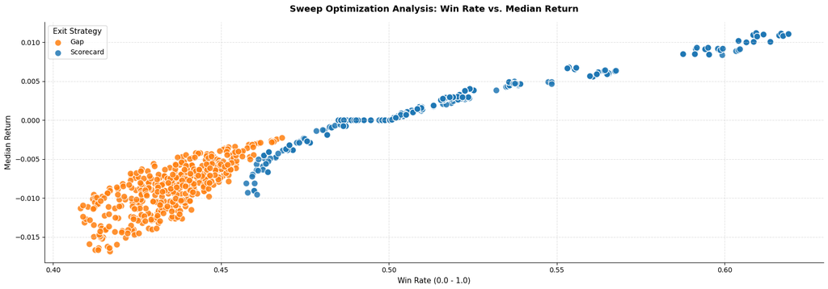

```python
plot_sweep_results(data)
```

### Observation

There is a clear separation between the `gap` and `scorecard` results - none of the `gap` exit strategy were ever profitable compared to `scorecard`. Likely because scorecard has about twice the amount of data, and has the option to exit either `open` or `close` when suitable, while `gap` only has the `close` option.

I also did a sanity check by bringing in the `v3_nasdaq` functions, and reproduced the same results regardless.

### Nan in `exit_on_consec_losses`

I forgot to track `exit_on_consec_losses`, therefore we have `Nan` values in the column - to prevent errors, I've decided to set them to my default value of `2`. Its not entirely accurate because I did use `3` for `gap` on some iterations, but it's the best I can do without backtesting.

```python
# 1. Fill the missing NaN values with 2
data["exit_on_consec_losses"] = data["exit_on_consec_losses"].fillna(2)

# 2. Save the updated DataFrame back to your CSV file
data.to_csv("run_params.csv", index=False)
```

```python
import os
from datetime import datetime
import numpy as np
import pandas as pd
from tqdm import tqdm  # <--- Make sure to run !pip install tqdm if not installed
```

```python
def evaluate_combined_andor_strategies_sampled(
    trade_file="trade_events.csv",
    run_file="run_params.csv",
    export_file="run_params_andor.csv",
    df_price_history=None,
    sample_pct=0.10,      # Capped at 10% to prevent RAM explosion
    random_seed=42        # Ensures you can replicate results
):
    """Pairs a 10% random sample of gap and scorecard parameter variations

    to calculate AND / OR trade performance profiles safely inside RAM.
    """
    import os
    from datetime import datetime
    import numpy as np
    import pandas as pd
    from tqdm import tqdm

    # 1. Validation Checks
    if not os.path.exists(trade_file) or not os.path.exists(run_file):
        print("Error: Missing required input CSV logs. Run your sweeps first!")
        return None

    if df_price_history is None:
        print("Error: Please provide 'df_price_history' to map returns correctly.")
        return None

    print("Loading indexing logs from disk...")
    runs = pd.read_csv(run_file)
    events = pd.read_csv(trade_file)

    # Attach strategy labels to events map
    events = events.merge(runs[["run_id", "exit_strategy"]], on="run_id", how="inner")

    # Separate strategy buffers
    gap_events = events[events["exit_strategy"] == "gap"].copy()
    score_events = events[events["exit_strategy"] == "scorecard"].copy()

    # ==================================================
    # 2. THE RAM SAVER: RANDOM SAMPLE COMPRESSION
    # ==================================================
    print("Extracting unique configuration keys...")
    unique_gaps = gap_events["run_id"].unique()
    unique_scores = score_events["run_id"].unique()

    # Calculate sample target size dimensions
    gap_sample_size = max(1, int(len(unique_gaps) * sample_pct))
    score_sample_size = max(1, int(len(unique_scores) * sample_pct))

    print(f"Sampling {gap_sample_size} gap runs out of {len(unique_gaps)}")
    print(f"Sampling {score_sample_size} scorecard runs out of {len(unique_scores)}")

    # Secure randomized array indexes
    np.random.seed(random_seed)
    sampled_gap_ids = np.random.choice(unique_gaps, size=gap_sample_size, replace=False)
    sampled_score_ids = np.random.choice(unique_scores, size=score_sample_size, replace=False)

    # Clean subset filters
    gap_trades = gap_events[gap_events["run_id"].isin(sampled_gap_ids)].copy()
    score_trades = score_events[score_events["run_id"].isin(sampled_score_ids)].copy()

    print(f"Performing safe relational pairing join on sampled subset...")
    paired = pd.merge(
        gap_trades,
        score_trades,
        on=["ticker", "entry_idx"],
        suffixes=("_gap", "_score")
    )

    if paired.empty:
        print("No matching trade events found with shared tickers and positions!")
        return None

    # ==================================================
    # 3. LOGICAL AND / OR MATRIX TRANSFORMS
    # ==================================================
    print("Calculating strategic logical exit boundaries...")
    paired["exit_idx_or"] = np.minimum(paired["exit_idx_gap"], paired["exit_idx_score"])
    paired["hold_days_or"] = paired["exit_idx_or"] - paired["entry_idx"]

    paired["exit_idx_and"] = np.maximum(paired["exit_idx_gap"], paired["exit_idx_score"])
    paired["hold_days_and"] = paired["exit_idx_and"] - paired["entry_idx"]

    # ==================================================
    # 4. HIGH PERFORMANCE VECTORIZED PRICING
    # ==================================================
    print("Pre-indexing asset price vectors into dictionary hashes...")
    price_maps = {
        t: g.sort_values("Date").reset_index(drop=True)["Close"].values
        for t, g in df_price_history.groupby("Ticker")
    }

    returns_or = np.empty(len(paired))
    returns_and = np.empty(len(paired))

    tickers = paired["ticker"].values
    entry_indices = paired["entry_idx"].values.astype(int)
    or_indices = paired["exit_idx_or"].values.astype(int)
    and_indices = paired["exit_idx_and"].values.astype(int)

    print("Executing vectorized baseline return extractions...")
    for idx in range(len(paired)):
        ticker = tickers[idx]
        if ticker not in price_maps:
            returns_or[idx] = np.nan
            returns_and[idx] = np.nan
            continue

        closes = price_maps[ticker]
        entry_p = closes[entry_indices[idx]]

        or_idx = min(or_indices[idx], len(closes) - 1)
        and_idx = min(and_indices[idx], len(closes) - 1)

        returns_or[idx] = (closes[or_idx] - entry_p) / entry_p
        returns_and[idx] = (closes[and_idx] - entry_p) / entry_p

    paired["return_or"] = returns_or
    paired["return_and"] = returns_and

    paired["ret_per_day_or"] = np.where(paired["hold_days_or"] > 0, paired["return_or"] / paired["hold_days_or"], paired["return_or"])
    paired["ret_per_day_and"] = np.where(paired["hold_days_and"] > 0, paired["return_and"] / paired["hold_days_and"], paired["return_and"])

    # ==================================================
    # 5. PROGRESS BAR LOOP (METRICS AGGREGATOR)
    # ==================================================
    grouped = paired.groupby(["run_id_gap", "run_id_score"])
    total_groups = len(grouped)

    print(f"Evaluating {total_groups:,} paired combination matrix groups.")

    or_start_idx = 0
    and_start_idx = 0

    if os.path.exists(export_file) and os.path.getsize(export_file) > 0:
        try:
            existing_output = pd.read_csv(export_file)
            or_runs = existing_output[existing_output["run_id"].str.startswith("or_", na=False)]["run_id"]
            and_runs = existing_output[existing_output["run_id"].str.startswith("and_", na=False)]["run_id"]

            if not or_runs.empty:
                or_start_idx = or_runs.str.extract(r'(\d+)').astype(int).max().iloc + 1
            if not and_runs.empty:
                and_start_idx = and_runs.str.extract(r'(\d+)').astype(int).max().iloc + 1
        except Exception:
            pass

    export_rows = []

    print("\nProcessing combinations grid metrics:")
    for (gap_id, score_id), group in tqdm(grouped, total=total_groups, desc="Sampled Matrix Pairs", unit="pair"):
        ret_or = group["return_or"].values
        ret_and = group["return_and"].values

        # SWAPPED: Changed np.mean and np.median to np.nanmean and np.nanmedian to handle hidden NaN trades safely
        export_rows.append({
            "run_id": f"or_{or_start_idx}",
            "exit_strategy": "or",
            "gap_id": gap_id,
            "score_id": score_id,
            "timestamp": datetime.now().strftime("%Y-%m-%d %H:%M:%S.%f"),
            "n_trades": len(group),
            "mean_return": np.nanmean(ret_or),
            "median_return": np.nanmedian(ret_or),
            "win_rate": np.nanmean(ret_or > 0),
            "avg_return_per_day": group["ret_per_day_or"].mean()
        })
        or_start_idx += 1

        # SWAPPED: Changed np.mean and np.median to np.nanmean and np.nanmedian to handle hidden NaN trades safely
        export_rows.append({
            "run_id": f"and_{and_start_idx}",
            "exit_strategy": "and",
            "gap_id": gap_id,
            "score_id": score_id,
            "timestamp": datetime.now().strftime("%Y-%m-%d %H:%M:%S.%f"),
            "n_trades": len(group),
            "mean_return": np.nanmean(ret_and),
            "median_return": np.nanmedian(ret_and),
            "win_rate": np.nanmean(ret_and > 0),
            "avg_return_per_day": group["ret_per_day_and"].mean()
        })
        and_start_idx += 1

    df_export = pd.DataFrame(export_rows)

    if os.path.exists(export_file) and os.path.getsize(export_file) > 0:
        old_export = pd.read_csv(export_file)
        df_export = pd.concat([old_export, df_export], ignore_index=True)

    df_export.to_csv(export_file, index=False)
    print(f"Success! Logged sampled combinations directly to: {export_file}")

    return df_export
```

```python
evaluate_combined_andor_strategies_sampled(
    trade_file="trade_events.csv",
    run_file="run_params.csv",
    export_file="run_params_andor.csv",
    df_price_history=df,
    sample_pct=0.25,
    random_seed=35  )
```

```
Loading indexing logs from disk...
Extracting unique configuration keys...
Sampling 107 gap runs out of 431
Sampling 128 scorecard runs out of 513
Performing safe relational pairing join on sampled subset...
Calculating strategic logical exit boundaries...
Pre-indexing asset price vectors into dictionary hashes...
Executing vectorized baseline return extractions...
Evaluating 13,696 paired combination matrix groups.

Processing combinations grid metrics:
```

```
Success! Logged sampled combinations directly to: run_params_andor.csv
```

|  | run_id | exit_strategy | gap_id | score_id | timestamp | n_trades | mean_return | median_return | win_rate | avg_return_per_day |
| --- | --- | --- | --- | --- | --- | --- | --- | --- | --- | --- |
| 0 | or_0 | or | gap_10 | score_101 | 2026-06-14 11:44:33.058057 | 841 | 0.007032 | -0.005914 | 0.432818 | -0.002090 |
| 1 | and_0 | and | gap_10 | score_101 | 2026-06-14 11:44:33.058057 | 841 | 0.007057 | -0.009639 | 0.437574 | -0.002148 |
| 2 | or_1 | or | gap_10 | score_106 | 2026-06-14 11:44:33.059653 | 841 | 0.013871 | 0.002007 | 0.530321 | 0.000470 |
| 3 | and_1 | and | gap_10 | score_106 | 2026-06-14 11:44:33.060646 | 841 | 0.009395 | -0.005914 | 0.439952 | -0.002049 |
| 4 | or_2 | or | gap_10 | score_110 | 2026-06-14 11:44:33.060646 | 841 | 0.010143 | -0.002055 | 0.464923 | -0.001302 |
| ... | ... | ... | ... | ... | ... | ... | ... | ... | ... | ... |
| 72323 | and_13693 | and | gap_98 | score_78 | 2026-06-14 12:00:03.686885 | 9974 | 0.009039 | -0.013916 | 0.430820 | -0.003006 |
| 72324 | or_13694 | or | gap_98 | score_80 | 2026-06-14 12:00:03.687885 | 9974 | 0.008399 | -0.008259 | 0.432825 | -0.003583 |
| 72325 | and_13694 | and | gap_98 | score_80 | 2026-06-14 12:00:03.687885 | 9974 | 0.009261 | -0.012767 | 0.431422 | -0.002957 |
| 72326 | or_13695 | or | gap_98 | score_93 | 2026-06-14 12:00:03.688885 | 9974 | 0.009377 | -0.002369 | 0.466212 | -0.001661 |
| 72327 | and_13695 | and | gap_98 | score_93 | 2026-06-14 12:00:03.689885 | 9974 | 0.008640 | -0.010785 | 0.429818 | -0.002790 |

72328 rows × 10 columns

```python
def plot_sweep_results(df_runs,opacity):
    """Plots an XY scatter graph of Win Rate vs. Median Return

    directly from an in-memory DataFrame variable using only Matplotlib.
    """
    # 1. Safety Check to verify the DataFrame has data rows
    if df_runs is None or df_runs.empty:
        print("Error: The provided DataFrame is empty or None!")
        return

    # 2. Clean strategy text labels inside the active memory buffer
    df_runs = df_runs.copy()
    df_runs["exit_strategy"] = df_runs["exit_strategy"].str.strip().str.lower()

    # 3. Setup Plot Configuration Canvas
    fig, ax = plt.subplots(figsize=(17, 6), dpi=100)
    ax.grid(True, linestyle="--", alpha=0.6, color="#cccccc")

    # Defined color map matching strategy labels
    color_map = {"and": "#1f77b4", "or": "#ff7f0e"}

    # 4. Group by Strategy and Plot Markers
    for strategy, group in df_runs.groupby("exit_strategy"):
        color = color_map.get(strategy, "#7f7f7f")  # Fallback to grey if unknown

        ax.scatter(
            group["win_rate"],
            group["median_return"],
            color=color,
            label=strategy.capitalize(),
            s=90,  # Dot size
            alpha=opacity,
            edgecolors="#ffffff",
            linewidths=1.0,
        )

    # 5. Labels, Grid Layouts and Title Configurations
    ax.set_title(
        "Sweep Optimization Analysis: AND vs. OR for gap/scorecard",
        fontsize=13,
        fontweight="bold",
        pad=15,
    )
    ax.set_xlabel("Win Rate (0.0 - 1.0)", fontsize=11, fontweight="medium")
    ax.set_ylabel("Median Return", fontsize=11, fontweight="medium")

    # 6. Customize Legend Configuration Settings
    ax.legend(
        title="Exit Strategy",
        title_fontsize="11",
        fontsize="10",
        loc="upper left",
        frameon=True,
        facecolor="#ffffff",
        edgecolor="#cccccc",
    )

    # Clean borders
    ax.spines["top"].set_visible(False)
    ax.spines["right"].set_visible(False)

    plt.tight_layout()
    plt.show()
```

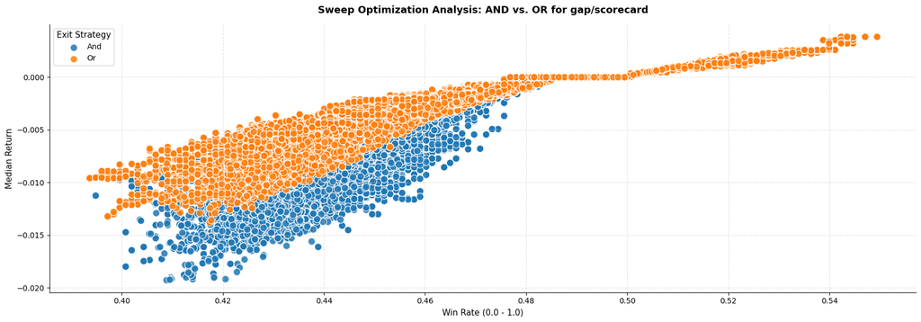

```python
andor_combine = 'run_params_andor.csv' # vix data
andor_data = pd.read_csv(andor_combine)
plot_sweep_results(andor_data,opacity=0.85)
```

### Observation

There's another clear difference between `And` and `Or`, where the former underperforms from the latter. It seems that when the market hits during volatility, the crash and fall can hit very rapidly, making the exit timeliness being very important. With the graph, the `Or` covers the `And`, so will severely decrease the opacity of the dots to see how `And` is placed.

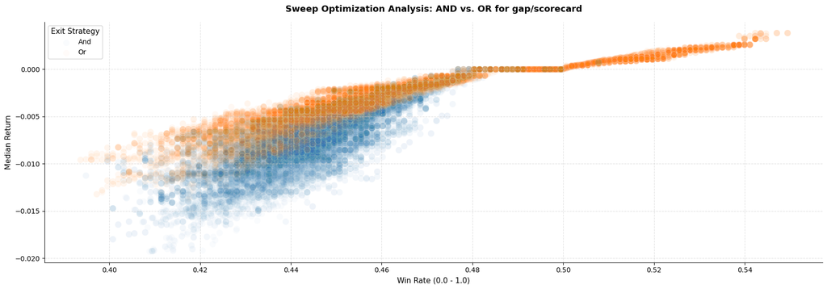

```python
plot_sweep_results(andor_data,opacity=0.025)
```

Let's zoom in on the data from 50% win, and 0% median return.

```python
andor_data_filtered = andor_data[(andor_data["win_rate"] > 0.50) & (andor_data["median_return"] > 0)]
plot_sweep_results(andor_data_filtered,opacity=0.85)
```

[figure not shown]

### OR observation:

I notice 3 separate distinct patterns on the `OR` positive data - the `Blue` had some slight randomized variations in returns, following a pretty linear path, ending around the low `0.52 win_rate`, and `>0.0020 median_return`. `Green` circeled area shows a very particular pattern, where only specific win rates are possible, leaving these gaps in between the next dotted points - and all these gaps are roughly equidistant from each other as well. The only variation is the `median_return` values, which is a strange oddity. Next the `Red` is an isolated group towards the top right corner that exhibits very similar qualities as the `Green` area.

I noticed the `AND/OR` has actually underperformed comparative to the `Scorecard` exit strategy itself, where its likely possible the `Gap` exit strategy is exiting too early in the stock. Let's check the positive results.

```python
data_filtered = data[(data["exit_strategy"] == 'scorecard')]
data_filtered = data_filtered[(data_filtered["win_rate"] > 0.50) & (data_filtered["median_return"] > 0)]
plot_sweep_results(data_filtered,opacity=0.85)
```

[figure not shown]

### SCORECARD observation:

`Blue` area showed a typical climb for both variables, with a general slowdown when increasing `median_returns` and a notable break in the data right before reaching `0.54 win_rate`. Beyond it is `Green`, where there is a smaller cluster that has some variability, and an actual gradual increase of `median_returns`, where it's momentum is passing the `Blue` area. Though similarly to the former, the data is both varied in `win` and `median`, but to a larger extent. Next is `Red`, sitting with a very large empty gap between green, where `0.57 - 0.59 win_rate` is empty. The area has a similar ailment to our previous `OR` graph, showing clustering of certain `win_rates` with only slight variability of `median_returns`, upwards to `0.62 win_rate` and `>0.010 median_return`.

> So how can we decide the most optimal options?

I've sent the information to google's AI bot, and it suggests to find the most optimal solution via a form of `efficiency_score`. Where returns, win rate, avg per day % etc. are all ordered from highest or lowest - whoever has the best rank out of all 4 combined, would be the chosen one.

```python
def rank_and_find_best_strategy(df_runs):
    """Ranks all configurations across all 4 metrics evenly to find the

    most robust mathematical winner. Drops duplicate performance rows.
    """
    if df_runs is None or df_runs.empty:
        print("Error: The provided DataFrame is empty!")
        return None

    # 1. Work on a clean copy
    ranked_df = df_runs.copy()

    # SWAPPED: Drop rows that share identical values across all 4 core dimensions
    metrics_subset = [
        "mean_return",
        "median_return",
        "win_rate",
        "avg_return_per_day",
    ]
    initial_count = len(ranked_df)
    ranked_df = ranked_df.drop_duplicates(subset=metrics_subset, keep="first")
    dropped_count = initial_count - len(ranked_df)

    # 2. Convert each metric into a normalized percentile rank (0.0 to 1.0)
    # pct=True makes the highest value score 1.0, and the lowest score 0.0
    ranked_df["rank_mean"] = ranked_df["mean_return"].rank(
        pct=True, na_option="bottom"
    )
    ranked_df["rank_median"] = ranked_df["median_return"].rank(
        pct=True, na_option="bottom"
    )
    ranked_df["rank_win"] = ranked_df["win_rate"].rank(
        pct=True, na_option="bottom"
    )
    ranked_df["rank_per_day"] = ranked_df["avg_return_per_day"].rank(
        pct=True, na_option="bottom"
    )

    # 3. Calculate the Composite Score (Max possible score is 4.0)
    ranked_df["overall_score"] = (
        ranked_df["rank_mean"]
        + ranked_df["rank_median"]
        + ranked_df["rank_win"]
        + ranked_df["rank_per_day"]
    )

    # 4. Sort by the highest overall score
    ranked_df = ranked_df.sort_values(
        by="overall_score", ascending=False
    ).reset_index(drop=True)

    # 5. Print the Winners Cleanly
    print(
        f"Evaluated {len(ranked_df)} unique variations (Skipped {dropped_count} duplicates) across 4 dimensions."
    )
    print("\n==================================================")
    print("      🏆 TOP 10 MATHEMATICALLY OPTIMAL RUNS       ")
    print("==================================================")

    for i in range(min(10, len(ranked_df))):
        row = ranked_df.iloc[i]
        print(
            f"\n🥇 RANK #{i+1}: Run ID '{row['run_id']}' (Strategy: {row['exit_strategy'].upper()})"
        )
        print(f" -> Overall Balanced Score: {row['overall_score']:.3f} / 4.000")
        print(f" -> [1] Win Rate:           {row['win_rate']:.2%}")
        print(f" -> [2] Median Return:      {row['median_return']:.4f}")
        print(f" -> [3] Mean Return:        {row['mean_return']:.4f}")
        print(f" -> [4] Return Per Day:     {row['avg_return_per_day']:.6f}")

        # If this is from your AND/OR combined file, print the lineage links
        if "gap_id" in ranked_df.columns and "score_id" in ranked_df.columns:
            print(
                f" -> Relational Lineage:     Uses {row['gap_id']} paired with {row['score_id']}\n"
            )

    return ranked_df
```

```python
optimized_results_df = rank_and_find_best_strategy(andor_data_filtered)
```

```
Evaluated 1713 unique variations (Skipped 3575 duplicates) across 4 dimensions.

==================================================
      🏆 TOP 10 MATHEMATICALLY OPTIMAL RUNS
==================================================

🥇 RANK #1: Run ID 'or_5367' (Strategy: OR)
 -> Overall Balanced Score: 3.986 / 4.000
 -> [1] Win Rate:           54.70%
 -> [2] Median Return:      0.0038
 -> [3] Mean Return:        0.0198
 -> [4] Return Per Day:     0.001346
 -> Relational Lineage:     Uses gap_332 paired with score_370


🥇 RANK #2: Run ID 'or_4347' (Strategy: OR)
 -> Overall Balanced Score: 3.981 / 4.000
 -> [1] Win Rate:           54.34%
 -> [2] Median Return:      0.0038
 -> [3] Mean Return:        0.0201
 -> [4] Return Per Day:     0.001357
 -> Relational Lineage:     Uses gap_286 paired with score_370


🥇 RANK #3: Run ID 'or_7030' (Strategy: OR)
 -> Overall Balanced Score: 3.979 / 4.000
 -> [1] Win Rate:           54.34%
 -> [2] Median Return:      0.0038
 -> [3] Mean Return:        0.0197
 -> [4] Return Per Day:     0.001361
 -> Relational Lineage:     Uses gap_396 paired with score_502


🥇 RANK #4: Run ID 'or_5194' (Strategy: OR)
 -> Overall Balanced Score: 3.970 / 4.000
 -> [1] Win Rate:           54.46%
 -> [2] Median Return:      0.0032
 -> [3] Mean Return:        0.0196
 -> [4] Return Per Day:     0.001337
 -> Relational Lineage:     Uses gap_325 paired with score_502
```

[output cut: 39 more lines]

```
 -> Overall Balanced Score: 3.952 / 4.000
 -> [1] Win Rate:           54.10%
 -> [2] Median Return:      0.0026
 -> [3] Mean Return:        0.0200
 -> [4] Return Per Day:     0.001344
 -> Relational Lineage:     Uses gap_279 paired with score_502


🥇 RANK #10: Run ID 'or_7509' (Strategy: OR)
 -> Overall Balanced Score: 3.950 / 4.000
 -> [1] Win Rate:           54.22%
 -> [2] Median Return:      0.0032
 -> [3] Mean Return:        0.0189
 -> [4] Return Per Day:     0.001260
 -> Relational Lineage:     Uses gap_46 paired with score_370
```

```python
score_results_df = rank_and_find_best_strategy(data_filtered)
```

```
Evaluated 119 unique variations (Skipped 254 duplicates) across 4 dimensions.

==================================================
      🏆 TOP 10 MATHEMATICALLY OPTIMAL RUNS
==================================================

🥇 RANK #1: Run ID 'score_264' (Strategy: SCORECARD)
 -> Overall Balanced Score: 3.975 / 4.000
 -> [1] Win Rate:           61.89%
 -> [2] Median Return:      0.0111
 -> [3] Mean Return:        0.0291
 -> [4] Return Per Day:     0.003422

🥇 RANK #2: Run ID 'score_156' (Strategy: SCORECARD)
 -> Overall Balanced Score: 3.933 / 4.000
 -> [1] Win Rate:           61.68%
 -> [2] Median Return:      0.0112
 -> [3] Mean Return:        0.0282
 -> [4] Return Per Day:     0.003406

🥇 RANK #3: Run ID 'score_480' (Strategy: SCORECARD)
 -> Overall Balanced Score: 3.882 / 4.000
 -> [1] Win Rate:           61.15%
 -> [2] Median Return:      0.0110
 -> [3] Mean Return:        0.0298
 -> [4] Return Per Day:     0.003088

🥇 RANK #4: Run ID 'score_263' (Strategy: SCORECARD)
 -> Overall Balanced Score: 3.866 / 4.000
 -> [1] Win Rate:           61.73%
 -> [2] Median Return:      0.0108
 -> [3] Mean Return:        0.0281
 -> [4] Return Per Day:     0.003362

🥇 RANK #5: Run ID 'score_372' (Strategy: SCORECARD)
 -> Overall Balanced Score: 3.857 / 4.000
 -> [1] Win Rate:           60.93%
 -> [2] Median Return:      0.0112
 -> [3] Mean Return:        0.0290
 -> [4] Return Per Day:     0.003025
```

[output cut: 20 more lines]

```
 -> [4] Return Per Day:     0.003009

🥇 RANK #9: Run ID 'score_371' (Strategy: SCORECARD)
 -> Overall Balanced Score: 3.748 / 4.000
 -> [1] Win Rate:           60.85%
 -> [2] Median Return:      0.0109
 -> [3] Mean Return:        0.0279
 -> [4] Return Per Day:     0.002970

🥇 RANK #10: Run ID 'score_154' (Strategy: SCORECARD)
 -> Overall Balanced Score: 3.723 / 4.000
 -> [1] Win Rate:           60.86%
 -> [2] Median Return:      0.0101
 -> [3] Mean Return:        0.0260
 -> [4] Return Per Day:     0.003279
```

```python
target_row = data_filtered[data_filtered["run_id"] == "score_264"]
target_row
```

|  | run_id | exit_strategy | exit_strat_delay | check_gap_first | check_gap_rest | intraday_weight | overnight_weight | exit_score_threshold | stop_loss_pct | entry_delay | timestamp | n_trades | mean_return | median_return | win_rate | avg_return_per_day | exit_on_consec_losses |
| --- | --- | --- | --- | --- | --- | --- | --- | --- | --- | --- | --- | --- | --- | --- | --- | --- | --- |
| 695 | score_264 | scorecard | 3 | 1 | 2 | 1.25 | 1.25 | 2 | -0.07 | 2 | 2026-06-13 22:09:56.461969 | 9958 | 0.029146 | 0.011076 | 0.618899 | 0.003422 | 2.0 |

# Conclusion:

To bring back the exit strategy results back to the filtered signal, I will first do `run_sweep` on two separate instances. One on `Scorecard`, and the other with `OR`. It's amazing how `Scorecard` is able to reach 60% win rate from a very simple strategy, which made me feel very skeptical about the returns, being overfitted on the randomized tickers.

The `OR` option is more of a sort of control/sanity check on returns as it adds a bit more variability and complexity. Once both tests have been fitted with the best hyperparams, weighing `median return` to `amount of data`, I can perform one more check on the other top 9 results, and see whether their high returns on randomized data, is effective with the other set of parameters. Maybe the 5th best results in randomization, outperforms the top result!

# Update redo:

Lol I knew to be suspicious of `scorecard` results! During proofreading, it was missing an instruction to exit at `close` when the points accumulated reached to `close`. Instead, it only had an `open` exit, leading to lookahead bias results.

This means ALL scorecard records need to be deleted and redone, then recalculate AND/OR returns - the distribution of AND/OR will likely stay the same, but much heavily reduced in terms of effectiveness.

Before continuing, I have updated scorecard and firstly sanity check return details.

```
supposed best results:
exit_strategy	exit_strat_delay	intraday_weight	overnight_weight	exit_score_threshold	stop_loss_pct	entry_delay	 exit_on_consec_losses
scorecard	     3	                   1.25           	1.25	           2                    	-0.07         	2	            2.0
```

```
n_trades	mean_return  	median_return	win_rate	avg_return_per_day
9958         	0.029146 	0.011076       0.618899	     0.003422
```

```python
trade_details = compute_trade_returns(df_open_long, df, true_signals,
                                      max_hold=100,exit_strategy='scorecard',exit_strat_delay=3, exit_on_consec_losses=2, overnight_weight=1.25,intraday_weight=1.25, exit_score_threshold=2, stop_loss_pct=-.07, entry_delay=2,
                                      entry_at="close", exit_at="close" )
```

```python
print(f"Average return: {(trade_details['return'].mean())*100:.4f}%")
print(f"Median return: {(trade_details['return'].median())*100:.4f}%")
print(f"Average hold days:", (trade_details['hold_days']).mean())
avg_gain_per_day = (trade_details['return'] / trade_details['hold_days']).mean() * 100
print(f"Average % gain per day: {avg_gain_per_day:.4f}%")
print(f"win_rate: {(trade_details['return'] > 0).mean()*100:.4f}%")
print(len(trade_details))
```

```
Average return: 2.0159%
Median return: 0.6198%
Average hold days: 7.038260694918659
Average % gain per day: 0.2393%
win_rate: 57.6923%
9958
```

I've double sanity checked by flipping the new exit for `close` back to `open`, and showed slightly better results than what was achieved from `run_sweep`. But even with the extra exit for `close`, `scorecard` still performed much better than anticipated.

Regardless of its good results, I want to redo the sweep on `score` to keep the integrity and accuracy of the data.

### Redoing entire sweep

During my insanity to get run_sweep to run in parallel for faster results, somehow the whole csv is fucking wiped - meaning the runs will have to be backtest entirely due to missing data.

```python
param_grid = {
    "check_gap_first": [1,2,3],
    "check_gap_rest": [2,1,3],

    "exit_strat_delay": [2,3,1],
    "entry_delay": [2,1,3],
    "stop_loss_pct": [-0.05,-0.07,-0.10,-0.025],
    "exit_on_consec_losses": [2,3],

    "exit_score_threshold": [2],
    "intraday_weight": [1],
    "overnight_weight": [1],

    "strategy" : ["gap"]
}
```

```python
all_results = run_sweep(
    df_open_long,
    df,
    true_signals,
    param_grid,
)
```

```python
evaluate_combined_andor_strategies_sampled(
    trade_file="trade_events.csv",
    run_file="run_params.csv",
    export_file="run_params_andor.csv",
    df_price_history=df,
    sample_pct=0.1,
    random_seed=35  )
```

```
Loading indexing logs from disk...
Extracting unique configuration keys...
Sampling 64 gap runs out of 648
Sampling 341 scorecard runs out of 3413
Performing safe relational pairing join on sampled subset...
Calculating strategic logical exit boundaries...
Pre-indexing asset price vectors into dictionary hashes...
Executing vectorized baseline return extractions...
Evaluating 21,824 paired combination matrix groups.

Processing combinations grid metrics:
```

```
Success! Logged sampled combinations directly to: run_params_andor.csv
```

|  | run_id | exit_strategy | gap_id | score_id | timestamp | n_trades | mean_return | median_return | win_rate | avg_return_per_day |
| --- | --- | --- | --- | --- | --- | --- | --- | --- | --- | --- |
| 0 | or_0 | or | gap_103 | score_1010 | 2026-06-17 19:09:33.113162 | 840 | 0.010700 | 0.000000 | 0.485714 | -0.000917 |
| 1 | and_0 | and | gap_103 | score_1010 | 2026-06-17 19:09:33.114163 | 840 | 0.001599 | -0.006004 | 0.448810 | -0.001917 |
| 2 | or_1 | or | gap_103 | score_1027 | 2026-06-17 19:09:33.116163 | 840 | 0.003305 | -0.005578 | 0.438095 | -0.002430 |
| 3 | and_1 | and | gap_103 | score_1027 | 2026-06-17 19:09:33.117163 | 840 | 0.004573 | -0.010955 | 0.423810 | -0.002269 |
| 4 | or_2 | or | gap_103 | score_1051 | 2026-06-17 19:09:33.118164 | 840 | 0.002106 | -0.006750 | 0.423810 | -0.004080 |
| ... | ... | ... | ... | ... | ... | ... | ... | ... | ... | ... |
| 43643 | and_21821 | and | gap_80 | score_963 | 2026-06-17 19:09:49.240011 | 835 | 0.009339 | -0.001065 | 0.469461 | -0.002036 |
| 43644 | or_21822 | or | gap_80 | score_991 | 2026-06-17 19:09:49.240011 | 835 | 0.009329 | -0.001416 | 0.463473 | -0.002328 |
| 43645 | and_21822 | and | gap_80 | score_991 | 2026-06-17 19:09:49.240011 | 835 | 0.020460 | -0.007540 | 0.445509 | -0.001934 |
| 43646 | or_21823 | or | gap_80 | score_998 | 2026-06-17 19:09:49.241011 | 835 | 0.006042 | 0.000000 | 0.481437 | -0.001289 |
| 43647 | and_21823 | and | gap_80 | score_998 | 2026-06-17 19:09:49.241011 | 835 | 0.008860 | -0.002110 | 0.463473 | -0.002144 |

43648 rows × 10 columns

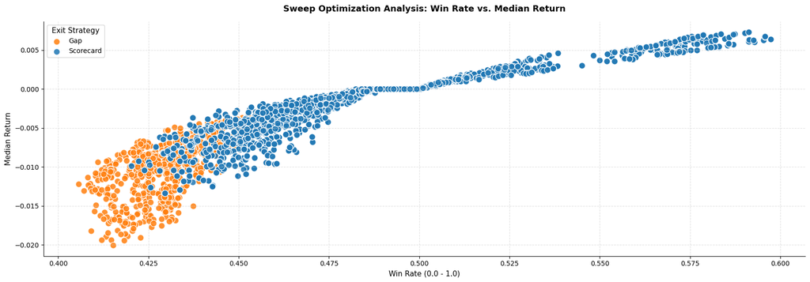

```python
run_params = 'run_params.csv' # vix data
data = pd.read_csv(run_params)
data.head()
plot_sweep_results(data)
```

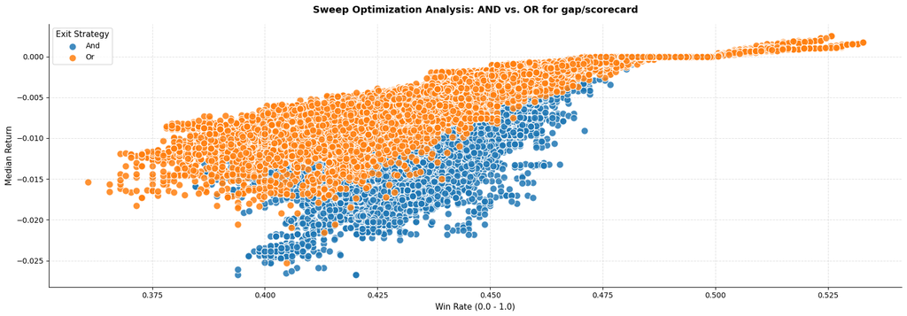

```python
andor_combine = 'run_params_andor.csv' # vix data
andor_data = pd.read_csv(andor_combine)
plot_sweep_results(andor_data,opacity=0.85)
```

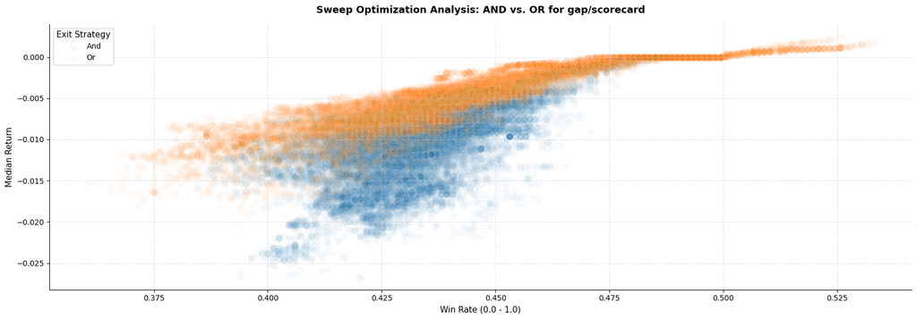

```python
plot_sweep_results(andor_data,opacity=0.03)
```

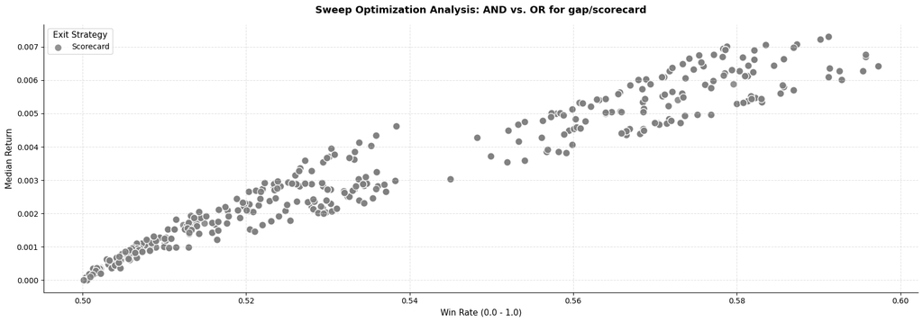

```python
data_filtered = data[(data["exit_strategy"] == 'scorecard')]
data_filtered = data_filtered[(data_filtered["win_rate"] > 0.50) & (data_filtered["median_return"] > 0)]
plot_sweep_results(data_filtered,opacity=0.85)
```

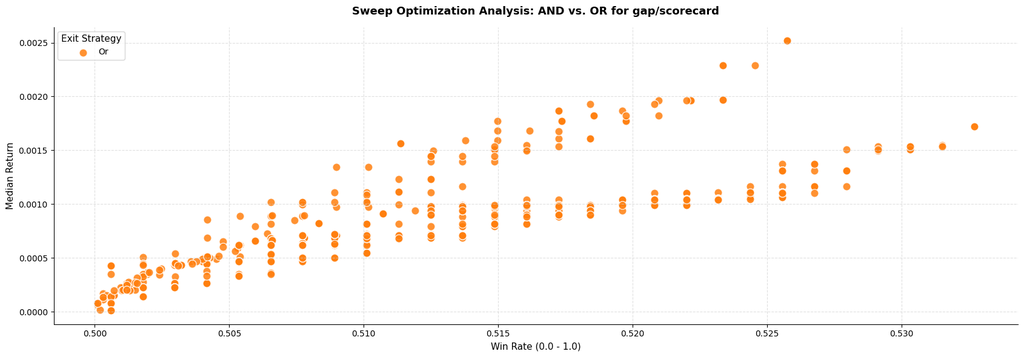

```python
andor_data_filtered = andor_data[(andor_data["win_rate"] > 0.50) & (andor_data["median_return"] > 0)]
plot_sweep_results(andor_data_filtered,opacity=0.85)
```

```python
optimized_results_df = rank_and_find_best_strategy(andor_data_filtered)
```

```
Evaluated 618 unique variations (Skipped 40 duplicates) across 4 dimensions.

==================================================
      🏆 TOP 10 MATHEMATICALLY OPTIMAL RUNS
==================================================

🥇 RANK #1: Run ID 'or_17180' (Strategy: OR)
 -> Overall Balanced Score: 3.882 / 4.000
 -> [1] Win Rate:           53.27%
 -> [2] Median Return:      0.0017
 -> [3] Mean Return:        0.0147
 -> [4] Return Per Day:     0.000460
 -> Relational Lineage:     Uses gap_515 paired with score_222


🥇 RANK #2: Run ID 'or_15415' (Strategy: OR)
 -> Overall Balanced Score: 3.843 / 4.000
 -> [1] Win Rate:           52.68%
 -> [2] Median Return:      0.0014
 -> [3] Mean Return:        0.0146
 -> [4] Return Per Day:     0.000856
 -> Relational Lineage:     Uses gap_460 paired with score_1722


🥇 RANK #3: Run ID 'or_4844' (Strategy: OR)
 -> Overall Balanced Score: 3.835 / 4.000
 -> [1] Win Rate:           52.68%
 -> [2] Median Return:      0.0014
 -> [3] Mean Return:        0.0144
 -> [4] Return Per Day:     0.000863
 -> Relational Lineage:     Uses gap_244 paired with score_1722


🥇 RANK #4: Run ID 'or_4222' (Strategy: OR)
 -> Overall Balanced Score: 3.830 / 4.000
 -> [1] Win Rate:           53.15%
 -> [2] Median Return:      0.0015
 -> [3] Mean Return:        0.0147
 -> [4] Return Per Day:     0.000357
 -> Relational Lineage:     Uses gap_229 paired with score_222
```

[output cut: 39 more lines]

```
 -> Overall Balanced Score: 3.807 / 4.000
 -> [1] Win Rate:           52.56%
 -> [2] Median Return:      0.0013
 -> [3] Mean Return:        0.0148
 -> [4] Return Per Day:     0.000817
 -> Relational Lineage:     Uses gap_77 paired with score_1722


🥇 RANK #10: Run ID 'or_3540' (Strategy: OR)
 -> Overall Balanced Score: 3.786 / 4.000
 -> [1] Win Rate:           53.03%
 -> [2] Median Return:      0.0015
 -> [3] Mean Return:        0.0145
 -> [4] Return Per Day:     0.000323
 -> Relational Lineage:     Uses gap_205 paired with score_222
```

```python
score_results_df = rank_and_find_best_strategy(data_filtered)
```

```
Evaluated 360 unique variations (Skipped 486 duplicates) across 4 dimensions.

==================================================
      🏆 TOP 10 MATHEMATICALLY OPTIMAL RUNS
==================================================

🥇 RANK #1: Run ID 'score_602' (Strategy: SCORECARD)
 -> Overall Balanced Score: 3.953 / 4.000
 -> [1] Win Rate:           59.12%
 -> [2] Median Return:      0.0073
 -> [3] Mean Return:        0.0241
 -> [4] Return Per Day:     0.003963

🥇 RANK #2: Run ID 'score_2486' (Strategy: SCORECARD)
 -> Overall Balanced Score: 3.936 / 4.000
 -> [1] Win Rate:           59.73%
 -> [2] Median Return:      0.0064
 -> [3] Mean Return:        0.0242
 -> [4] Return Per Day:     0.005087

🥇 RANK #3: Run ID 'score_614' (Strategy: SCORECARD)
 -> Overall Balanced Score: 3.933 / 4.000
 -> [1] Win Rate:           59.02%
 -> [2] Median Return:      0.0072
 -> [3] Mean Return:        0.0237
 -> [4] Return Per Day:     0.003938

🥇 RANK #4: Run ID 'score_2870' (Strategy: SCORECARD)
 -> Overall Balanced Score: 3.904 / 4.000
 -> [1] Win Rate:           59.57%
 -> [2] Median Return:      0.0068
 -> [3] Mean Return:        0.0233
 -> [4] Return Per Day:     0.003892

🥇 RANK #5: Run ID 'score_604' (Strategy: SCORECARD)
 -> Overall Balanced Score: 3.903 / 4.000
 -> [1] Win Rate:           58.73%
 -> [2] Median Return:      0.0071
 -> [3] Mean Return:        0.0234
 -> [4] Return Per Day:     0.003855
```

[output cut: 20 more lines]

```
 -> [4] Return Per Day:     0.003304

🥇 RANK #9: Run ID 'score_606' (Strategy: SCORECARD)
 -> Overall Balanced Score: 3.872 / 4.000
 -> [1] Win Rate:           58.69%
 -> [2] Median Return:      0.0070
 -> [3] Mean Return:        0.0229
 -> [4] Return Per Day:     0.003908

🥇 RANK #10: Run ID 'score_2882' (Strategy: SCORECARD)
 -> Overall Balanced Score: 3.871 / 4.000
 -> [1] Win Rate:           59.57%
 -> [2] Median Return:      0.0067
 -> [3] Mean Return:        0.0229
 -> [4] Return Per Day:     0.003881
```

```python
def compute_trade_returns(
    df_open,
    df_price_history,
    true_signal,
    max_hold=100,
    exit_on_consec_losses=2,
    stop_loss_pct=-0.05,
    entry_at="open",
    exit_at="close",
    entry_delay=5,
    exit_strategy="scorecard",  # NEW: default strategy
    # GAP strategy params
    exit_strat_delay=2,
    check_gap_first=1,
    check_gap_rest=2,
    # SCORE strategy params (optional future use)
    intraday_weight=1.0,
    overnight_weight=1.0,
    exit_score_threshold=4,
):

    # create list to keep our trade details and theoretical returns from entry and exit strategies
    trades = []

    # ==================================================
    # SIGNAL DATA
    # ==================================================
    df_open = df_open.sort_values(["Ticker", "Date"]).copy()
    df_open["Date"] = pd.to_datetime(df_open["Date"])

    # merge open price with full df
    df_price_history = df_price_history.merge(df_open[["Ticker", "Date", "Open"]], on=["Ticker", "Date"], how="left")

    # if open df is empty in any slots
    if df_price_history["Open"].isna().any():
        raise ValueError(
            f"{df_price_history['Open'].isna().sum()} rows missing Open prices after merge")

    # ==================================================
    # FULL PRICE HISTORY
    # ==================================================
    # Create a full price history dictionary, storing each ticker with prices, ordered by date (old to new)
    df_price_history["Date"] = pd.to_datetime(df_price_history["Date"])

    full_price_dict = {
        ticker: g.sort_values("Date").reset_index(drop=True)
        # sort date value sequentially per ticker, and reset index ordering from 0, then 1, etc. rather than previous index which would be misaligned.
        for ticker, g in df_price_history.groupby("Ticker")
        # grouping by tickers, along with their df rows:
        # AAPL, DF containing AAPL rows,
        # MSFT, DF containing MSFT rows
        # for ticker (Ticker name), g (other df data)
    }

    # ==================================================
    # ALIGN SIGNALS
    # ==================================================
    # Bring in true signals into the full df, so our code knows where our entry points are
    df = df_price_history.copy()

    df["signal"] = False # create boolean column for full df
    df.loc[true_signal.index, "signal"] = True # insert the true signals into said df column by index val

    # because our signal is triggered right at closing day of a stock, there must require a entry_delay to prevent lookahead bias
    # lowest value is 1, aka the following day of signal trigger
    signal_shifted = (
        df.groupby("Ticker")["signal"]
        .shift(entry_delay)
        .fillna(False)
        .astype(bool)
    )

    # ==================================================
    # MAIN LOOP
    # ==================================================
    # Begin using full_df with signals implanted to start calculating exit strategy
    for ticker, g in df_price_history.groupby("Ticker"): # execute loop per ticker
        # reset index starting from 0
        g = g.reset_index()
        # add signal entry locale, via the shifted signal variable
        sig_entry = signal_shifted.loc[g["index"]].values
        # find all valid entry index, by selecting the `True` out of `False`.
        entry_idxs = np.where(sig_entry)[0] # [0] tells np to grab the first item in the sequence, aka the long list of signal index where it is `True`

        # retrieval of full dataset - used to execute and simulate our trades
        if ticker not in full_price_dict:
            continue
        full_g = full_price_dict[ticker]

        # create loop that goes through every valid entries with their shifted signals
        for e in entry_idxs:
            # calculating entry index to find where signal index occured
            signal_idx = max(e - entry_delay, 0) # 0 is to prevent negative indexing, causing error
            # look up actual date of signal occurence for both entry index, and signal index
            signal_date = g.iloc[signal_idx]["Date"]
            entry_date = g.iloc[e]["Date"]

            # locate entry date inside FULL history per ticker
            full_match = full_g.index[full_g["Date"] == entry_date]
            # safety check in case full hist can't find a row that matches the entry date
            if len(full_match) == 0:
                continue

            # extracts matching index of entry date - grabbing row numbers of when trade begins
            full_entry_idx = full_match[0]
            # instantiate the full window of how long the hold can last based on criteria
            full_window = full_g.iloc[
                full_entry_idx : full_entry_idx + max_hold + 1
            ]

            # safety check to ensure full window has future data for evaluation - in case a signal occurs yesterday, it can't simulate holds and is thus skipped
            if len(full_window) <= 1:
                continue

            # get close and open variable from full df (set open to close if open doesn't exist)
            closes = full_window["Close"].values

            if "Open" in full_window.columns:
                opens = full_window["Open"].values
            else:
                opens = closes

            # set variable for entry price of stock based on signal (open/close entry is dictated as one of the variables called in)
            entry_price = (opens[0] if entry_at == "open" else closes[0])

            # ==================================================
            # EXIT STRATEGY (DELEGATED) - Have two options for which strategy to use - and the hyperparams to be used
            # ==================================================
            if exit_strategy == 'gap':
                exit_offset = gap_exit_strategy(
                    closes,
                    exit_strat_delay,
                    check_gap_first,
                    check_gap_rest,
                    exit_on_consec_losses,
                    stop_loss_pct)

            elif exit_strategy == 'scorecard':
                exit_offset, active_exit_at = score_exit_strategy( # an xtra output, to tell whether `open` or `close` is to be used
                    closes,
                    opens,
                    exit_strat_delay,
                    intraday_weight,
                    overnight_weight,
                    exit_score_threshold,
                    stop_loss_pct)

            else:
                raise ValueError("invalid strategy! Use 'gap' or 'scorecard'")

            # determines whether `open` or `close` is selected if `active_exit_at` exists. If not (such as using `gap` strategy), it will default to the exit param above (unless changed when called function)
            chosen_execution = active_exit_at if 'active_exit_at' in locals() else exit_at

            # set variable of exit price of stock, based on signal (open/close either from `exit_at`, or `active_exit` is present)
            exit_price = (opens[exit_offset] if chosen_execution == "open"else closes[exit_offset])

            # using signal_idx, which has been processed from the full df, to extract the rows of the filtered dataset that triggered entry
            signal_row = g.iloc[signal_idx]

            # print output for every signal tickers, and it's return/hold days.
            trades.append({
                "Ticker": ticker,
                "Date": entry_date,
                "signal_date": signal_date,
                "exit_strategy": exit_strategy,

                "entry_idx": full_entry_idx,
                "exit_idx": full_entry_idx + exit_offset,

                "Close": signal_row["Close"],

                "entry_price": entry_price,
                "exit_price": exit_price,
                "return": (exit_price - entry_price) / entry_price,
                "hold_days": exit_offset
            })

    # data is actually a dictionary - converting it into pandas df
    trades_df = pd.DataFrame(trades)

    # safety check to see if there are actual data in the df
    if len(trades_df):
        # then remove any missing or Nan values from 'exit_price' column
        trades_df = trades_df.dropna(subset=["exit_price"])

    return trades_df
```

```python
trade_details = compute_trade_returns(df_open_long, df, true_signals,
                                      max_hold=100,exit_strategy='scorecard', entry_delay=1 ,exit_strat_delay=2,
                                      exit_on_consec_losses=2, overnight_weight=1.25, intraday_weight=1.25, exit_score_threshold=2, stop_loss_pct=-.1,
                                      entry_at="open", exit_at="close")
```

```python
print(f"Average return: {(trade_details['return'].mean())*100:.4f}%")
print(f"Median return: {(trade_details['return'].median())*100:.4f}%")
print(f"Average hold days:", (trade_details['hold_days']).mean())
avg_gain_per_day = (trade_details['return'] / trade_details['hold_days']).mean() * 100
print(f"Average % gain per day: {avg_gain_per_day:.4f}%")
print(f"win_rate: {(trade_details['return'] > 0).mean()*100:.4f}%")
print(len(trade_details))
```

```
Average return: 2.4071%
Median return: 0.7304%
Average hold days: 6.183075997593744
Average % gain per day: 0.3963%
win_rate: 59.1237%
9974
```

## Random scorecard exit threshold test:

I decided to see how the stocks performed if I gave a random number to exit rather than 2, because that only allows two negatives to fully exit out of the trade. And the results were quite surprising.

I did some simple observing of different trades and compared them to each other, especially the negatives, and what happens is that most of the bad performing ticker under `2`, still performed as bad `7` - while that was the opposite for the well performing tickers. This sort of aligns with the strategy of exiting early when the stock keeps bleeding out such as the `-7%` rule.

To make this a little bit more robust, I'll redo my scorecard function again to allow for both the `short term` exit, and `long term` exit. Like how the gap strategy is, we will sell off stocks if x scores has reached and has not met earnings quota. Then beyond it, the y scores is then utilized to allow larger gains to be captured when surviving past a dip.

```python
def score_exit_strategy(
    closes,
    opens,
    exit_strat_delay,
    intraday_weight,
    overnight_weight,
    short_term_threshold,
    long_term_threshold,
    short_term_window,  # Number of periods the strict short-term rule applies
    stop_loss_pct,
):
    score = 0
    exit_offset = len(closes) - 1
    exit_type_override = "close"

    for j in range(exit_strat_delay, len(closes) - 1):
        # 1. Dynamically determine the active threshold based on time elapsed
        current_threshold = (
            short_term_threshold
            if (j - exit_strat_delay) < short_term_window # if the index position of the ticker, is within short term window, use the short term
            else long_term_threshold
        )

        # 2. Intraday Move
        intraday_move = closes[j] - opens[j]
        if intraday_move < 0:
            score += intraday_weight
        else:
            score = max(0, score - intraday_weight)

        # Check intraday score breach
        if score >= current_threshold:
            return j, "close"

        # 3. Hard Stop Loss (Percentage-based protection)
        if j > 0:
            pct_change = (closes[j] - closes[j - 1]) / closes[j - 1]
            if pct_change <= stop_loss_pct:
                return j, "close"

        # 4. Overnight Move
        if j + 1 < len(closes):
            overnight_move = opens[j + 1] - closes[j]

            if overnight_move < 0:
                score += overnight_weight
            else:
                score = max(0, score - overnight_weight)

        # Check overnight score breach
        if score >= current_threshold:
            return j, "open"

    return exit_offset, exit_type_override
```

```python
# run sweep

def compute_trade_returns(
    df_open,
    df_price_history,
    true_signal,
    run_id="default_run",
    max_hold=100,
    exit_on_consec_losses=2,
    stop_loss_pct=-0.05,
    entry_at="open",
    exit_at="close",
    entry_delay=5,
    exit_strategy="scorecard",
    # GAP
    exit_strat_delay=2,
    check_gap_first=1,
    check_gap_rest=2,
    # SCORE
    intraday_weight=1.0,
    overnight_weight=1.0,
    short_term_threshold=4,
    long_term_threshold=6,
    short_term_window=5
):
    trades = []

    # ==================================================
    # SIGNAL DATA
    # ==================================================
    df_open = df_open.sort_values(["Ticker", "Date"]).copy()
    df_open["Date"] = pd.to_datetime(df_open["Date"])

    df_price_history = df_price_history.merge(
        df_open[["Ticker", "Date", "Open"]], on=["Ticker", "Date"], how="left"
    )

    if df_price_history["Open"].isna().any():
        raise ValueError(
            f"{df_price_history['Open'].isna().sum()} rows missing Open prices"
        )

    df_price_history["Date"] = pd.to_datetime(df_price_history["Date"])

    full_price_dict = {
        t: g.sort_values("Date").reset_index(drop=True)
        for t, g in df_price_history.groupby("Ticker")
    }

    df = df_price_history.copy()
    df["signal"] = False
    df.loc[true_signal.index, "signal"] = True

    signal_shifted = (
        df.groupby("Ticker")["signal"]
        .shift(entry_delay)
        .fillna(False)
        .astype(bool)
    )

    # ==================================================
    # MAIN LOOP
    # ==================================================
    for ticker, g in df_price_history.groupby("Ticker"):
        g = g.reset_index()

        sig_entry = signal_shifted.loc[g["index"]].values
        entry_idxs = np.where(sig_entry)[0]

        if ticker not in full_price_dict:
            continue

        full_g = full_price_dict[ticker]

        for e in entry_idxs:
            signal_idx = max(e - entry_delay, 0)
            signal_date = g.iloc[signal_idx]["Date"]
            entry_date = g.iloc[e]["Date"]

            full_match = full_g.index[full_g["Date"] == entry_date]
            if len(full_match) == 0:
                continue

            full_entry_idx = full_match[0]

            window = full_g.iloc[
                full_entry_idx : full_entry_idx + max_hold + 1
            ]

            if len(window) <= 1:
                continue

            closes = window["Close"].values

            if "Open" in window.columns:
                opens = window["Open"].values
            else:
                opens = closes

            entry_price = opens[0] if entry_at == "open" else closes[0]

            # ==================================================
            # EXIT STRATEGY
            # ==================================================
            if exit_strategy == "gap":
                # SWAPPED: Single output assignment + fallback injection to protect against unpack errors
                exit_offset = gap_exit_strategy(
                    closes,
                    exit_strat_delay,
                    check_gap_first,
                    check_gap_rest,
                    exit_on_consec_losses,
                    stop_loss_pct,
                )
                active_exit_at = "close"

            elif exit_strategy == "scorecard":
                exit_offset, active_exit_at = score_exit_strategy(
                    closes,
                    opens,
                    exit_strat_delay,
                    intraday_weight,
                    overnight_weight,
                    short_term_threshold,
                    long_term_threshold,
                    short_term_window,
                    stop_loss_pct,
                )

            else:
                raise ValueError("exit_strategy must be 'gap' or 'scorecard'")

            # SWAPPED: Added a validation check to let active_exit_at fall back to the default exit_at setting
            chosen_execution = active_exit_at if 'active_exit_at' in locals() else exit_at
            exit_price = (
                opens[exit_offset]
                if chosen_execution == "open"
                else closes[exit_offset]
            )

            trades.append(
                {
                    "run_id": run_id,
                    "ticker": ticker,
                    "entry_date": entry_date,
                    "signal_date": signal_date,
                    "entry_idx": full_entry_idx,
                    "exit_idx": full_entry_idx + exit_offset,
                    "entry_price": entry_price,
                    "exit_price": exit_price,
                    "return": (exit_price - entry_price) / entry_price,
                    "hold_days": exit_offset,
                    "exit_strategy": exit_strategy,
                    # parameters snapshot (IMPORTANT FOR SWEEPS)
                    "exit_strat_delay": exit_strat_delay,
                    "check_gap_first": check_gap_first,
                    "check_gap_rest": check_gap_rest,
                    "intraday_weight": intraday_weight,
                    "overnight_weight": overnight_weight,
                    "short_term_threshold": short_term_threshold,
                    "long_term_threshold": long_term_threshold,
                    "short_term_window": short_term_window,
                    "stop_loss_pct": stop_loss_pct,
                    "entry_delay": entry_delay,
                }
            )

    trades_df = pd.DataFrame(trades)

    if len(trades_df) > 0:
        trades_df = trades_df.dropna(subset=["exit_price"])

    # ==================================================
    # CSV LOGGING (MINIMAL STRUCTURAL INDEXING)
    # ==================================================
    trade_file = "trade_events.csv"
    run_file = "run_params.csv"

    # Calculate average daily return profile per trade (avoiding division by zero)
    if len(trades_df) > 0:
        trades_df["return_per_day"] = np.where(
            trades_df["hold_days"] > 0,
            trades_df["return"] / trades_df["hold_days"],
            trades_df["return"],
        )

    # ---- trade log (ONLY run_id, ticker, entry_idx, exit_idx) ----
    if len(trades_df) > 0:
        trade_export = trades_df[
            ["run_id", "ticker", "entry_idx", "exit_idx"]
        ].copy()
    else:
        trade_export = pd.DataFrame(
            columns=["run_id", "ticker", "entry_idx", "exit_idx"]
        )

    if os.path.exists(trade_file) and os.path.getsize(trade_file) > 0:
        old = pd.read_csv(trade_file)
        trade_export = pd.concat([old, trade_export], ignore_index=True)

    trade_export.to_csv(trade_file, index=False)

    # ---- run params log + performance tracking ----
    run_row = pd.DataFrame(
        [
            {
                "run_id": run_id,
                "exit_strategy": exit_strategy,
                "exit_strat_delay": exit_strat_delay,
                "exit_on_consec_losses": exit_on_consec_losses,
                "check_gap_first": check_gap_first,
                "check_gap_rest": check_gap_rest,
                "intraday_weight": intraday_weight,
                "overnight_weight": overnight_weight,
                "short_term_threshold": short_term_threshold,
                "long_term_threshold": long_term_threshold,
                "short_term_window": short_term_window,
                "stop_loss_pct": stop_loss_pct,
                "entry_delay": entry_delay,
                "timestamp": datetime.now(),
                # Aggregated Metrics Relational Storage
                "n_trades": len(trades_df),
                "mean_return": trades_df["return"].mean() if len(trades_df) else 0,
                "median_return": (
                    trades_df["return"].median() if len(trades_df) else 0
                ),
                "win_rate": (
                    (trades_df["return"] > 0).mean() if len(trades_df) else 0
                ),
                "avg_return_per_day": (
                    trades_df["return_per_day"].mean() if len(trades_df) else 0
                ),
            }
        ]
    )

    # FIXED: Re-added the file append completion logic that cut off
    if os.path.exists(run_file) and os.path.getsize(run_file) > 0:
        old_runs = pd.read_csv(run_file)
        run_row = pd.concat([old_runs, run_row], ignore_index=True)

    run_row.to_csv(run_file, index=False)

    return trades_df
```

```python
def compute_trade_returns(
    df_open,
    df_price_history,
    true_signal,
    max_hold=100,
    exit_on_consec_losses=2,
    stop_loss_pct=-0.05,
    entry_at="open",
    exit_at="close",
    entry_delay=5,
    exit_strategy="scorecard",  # NEW: default strategy
    # GAP strategy params
    exit_strat_delay=2,
    check_gap_first=1,
    check_gap_rest=2,
    # SCORE strategy params (optional future use)
    intraday_weight=1.0,
    overnight_weight=1.0,
    short_term_threshold=4,
    long_term_threshold=6,
    short_term_window=4,
):

    # create list to keep our trade details and theoretical returns from entry and exit strategies
    trades = []

    # ==================================================
    # SIGNAL DATA
    # ==================================================
    df_open = df_open.sort_values(["Ticker", "Date"]).copy()
    df_open["Date"] = pd.to_datetime(df_open["Date"])

    # merge open price with full df
    df_price_history = df_price_history.merge(df_open[["Ticker", "Date", "Open"]], on=["Ticker", "Date"], how="left")

    # if open df is empty in any slots
    if df_price_history["Open"].isna().any():
        raise ValueError(
            f"{df_price_history['Open'].isna().sum()} rows missing Open prices after merge")

    # ==================================================
    # FULL PRICE HISTORY
    # ==================================================
    # Create a full price history dictionary, storing each ticker with prices, ordered by date (old to new)
    df_price_history["Date"] = pd.to_datetime(df_price_history["Date"])

    full_price_dict = {
        ticker: g.sort_values("Date").reset_index(drop=True)
        # sort date value sequentially per ticker, and reset index ordering from 0, then 1, etc. rather than previous index which would be misaligned.
        for ticker, g in df_price_history.groupby("Ticker")
        # grouping by tickers, along with their df rows:
        # AAPL, DF containing AAPL rows,
        # MSFT, DF containing MSFT rows
        # for ticker (Ticker name), g (other df data)
    }

    # ==================================================
    # ALIGN SIGNALS
    # ==================================================
    # Bring in true signals into the full df, so our code knows where our entry points are
    df = df_price_history.copy()

    df["signal"] = False # create boolean column for full df
    df.loc[true_signal.index, "signal"] = True # insert the true signals into said df column by index val

    # because our signal is triggered right at closing day of a stock, there must require a entry_delay to prevent lookahead bias
    # lowest value is 1, aka the following day of signal trigger
    signal_shifted = (
        df.groupby("Ticker")["signal"]
        .shift(entry_delay)
        .fillna(False)
        .astype(bool)
    )

    # ==================================================
    # MAIN LOOP
    # ==================================================
    # Begin using full_df with signals implanted to start calculating exit strategy
    for ticker, g in df_price_history.groupby("Ticker"): # execute loop per ticker
        # reset index starting from 0
        g = g.reset_index()
        # add signal entry locale, via the shifted signal variable
        sig_entry = signal_shifted.loc[g["index"]].values
        # find all valid entry index, by selecting the `True` out of `False`.
        entry_idxs = np.where(sig_entry)[0] # [0] tells np to grab the first item in the sequence, aka the long list of signal index where it is `True`

        # retrieval of full dataset - used to execute and simulate our trades
        if ticker not in full_price_dict:
            continue
        full_g = full_price_dict[ticker]

        # create loop that goes through every valid entries with their shifted signals
        for e in entry_idxs:
            # calculating entry index to find where signal index occured
            signal_idx = max(e - entry_delay, 0) # 0 is to prevent negative indexing, causing error
            # look up actual date of signal occurence for both entry index, and signal index
            signal_date = g.iloc[signal_idx]["Date"]
            entry_date = g.iloc[e]["Date"]

            # locate entry date inside FULL history per ticker
            full_match = full_g.index[full_g["Date"] == entry_date]
            # safety check in case full hist can't find a row that matches the entry date
            if len(full_match) == 0:
                continue

            # extracts matching index of entry date - grabbing row numbers of when trade begins
            full_entry_idx = full_match[0]
            # instantiate the full window of how long the hold can last based on criteria
            full_window = full_g.iloc[
                full_entry_idx : full_entry_idx + max_hold + 1
            ]

            # safety check to ensure full window has future data for evaluation - in case a signal occurs yesterday, it can't simulate holds and is thus skipped
            if len(full_window) <= 1:
                continue

            # get close and open variable from full df (set open to close if open doesn't exist)
            closes = full_window["Close"].values

            if "Open" in full_window.columns:
                opens = full_window["Open"].values
            else:
                opens = closes

            # set variable for entry price of stock based on signal (open/close entry is dictated as one of the variables called in)
            entry_price = (opens[0] if entry_at == "open" else closes[0])

            # ==================================================
            # EXIT STRATEGY (DELEGATED) - Have two options for which strategy to use - and the hyperparams to be used
            # ==================================================
            if exit_strategy == 'gap':
                exit_offset = gap_exit_strategy(
                    closes,
                    exit_strat_delay,
                    check_gap_first,
                    check_gap_rest,
                    exit_on_consec_losses,
                    stop_loss_pct)

            elif exit_strategy == 'scorecard':
                exit_offset, active_exit_at = score_exit_strategy( # an xtra output, to tell whether `open` or `close` is to be used
                    closes,
                    opens,
                    exit_strat_delay,
                    intraday_weight,
                    overnight_weight,
                    short_term_threshold,
                    long_term_threshold,
                    short_term_window,
                    stop_loss_pct)

            else:
                raise ValueError("invalid strategy! Use 'gap' or 'scorecard'")

            # determines whether `open` or `close` is selected if `active_exit_at` exists. If not (such as using `gap` strategy), it will default to the exit param above (unless changed when called function)
            chosen_execution = active_exit_at if 'active_exit_at' in locals() else exit_at

            # set variable of exit price of stock, based on signal (open/close either from `exit_at`, or `active_exit` is present)
            exit_price = (opens[exit_offset] if chosen_execution == "open"else closes[exit_offset])

            # using signal_idx, which has been processed from the full df, to extract the rows of the filtered dataset that triggered entry
            signal_row = g.iloc[signal_idx]

            # print output for every signal tickers, and it's return/hold days.
            trades.append({
                "Ticker": ticker,
                "Date": entry_date,
                "signal_date": signal_date,
                "exit_strategy": exit_strategy,

                "entry_idx": full_entry_idx,
                "exit_idx": full_entry_idx + exit_offset,

                "Close": signal_row["Close"],

                "entry_price": entry_price,
                "exit_price": exit_price,
                "return": (exit_price - entry_price) / entry_price,
                "hold_days": exit_offset
            })

    # data is actually a dictionary - converting it into pandas df
    trades_df = pd.DataFrame(trades)

    # safety check to see if there are actual data in the df
    if len(trades_df):
        # then remove any missing or Nan values from 'exit_price' column
        trades_df = trades_df.dropna(subset=["exit_price"])

    return trades_df
```

```python
trade_details = compute_trade_returns(df_open_long, df, true_signals,
                                      max_hold=100,exit_strategy='scorecard', entry_delay=1 ,exit_strat_delay=2,
                                      exit_on_consec_losses=2, overnight_weight=1.25, intraday_weight=1.25, short_term_threshold=7, long_term_threshold=7, short_term_window=1, stop_loss_pct=-.1,
                                      entry_at="open", exit_at="close")
```

```python
print(f"Average return: {(trade_details['return'].mean())*100:.4f}%")
print(f"Median return: {(trade_details['return'].median())*100:.4f}%")
print(f"Average hold days:", (trade_details['hold_days']).mean())
avg_gain_per_day = (trade_details['return'] / trade_details['hold_days']).mean() * 100
print(f"Average % gain per day: {avg_gain_per_day:.4f}%")
print(f"win_rate: {(trade_details['return'] > 0).mean()*100:.4f}%")
print(len(trade_details))
```

```
Average return: 2.0557%
Median return: -0.4823%
Average hold days: 28.90896330459194
Average % gain per day: -0.2080%
win_rate: 47.1125%
9974
```

It seems I've run into an issue... Selecting a randomized of 10k entry points of different tickers of a regime vix above 22, and sp500 environment of <0% gain in 10 trading days, which is the specific regime my stock picks are coming from, produce worse results when the tickers are held for longer under red. This typically makes sense as in a bearish market, there's a higher chance that stocks continue to bleed out. However caveat to the data that I have meticulously thresholed, signaled, and constrained provides the opposite effect, when I allow them to accumulate more red.

We'll have to perform the test under the strategy notebook, as randomized tests won't help us beyond here - at least it tells me what is most optimal when dealing with bleeding tickers.